# Computational analyses used on the manuscript: *Predictive regulatory and metabolic network models for systems analysis of Clostridioides difficile*

Mario Arrieta-Ortiz

March 25, 2021

0. Load required libraries

```r
library (DBI)
library(DESeq2)
library(GEOquery)
library(gplots)
library(ggplot2)
library(pheatmap)
library(RColorBrewer)
library (RSQLite)
library(viridis)
```

1.1 Load the compiled transcriptional compendium

```r
#this script generates the transcriptional compendium
#source("create_transcriptional_compendium.R")
#read the collected compendium
transcriptomes<-read.csv("../Data/EGRIN/Input/Cdifficile630_transcriptional_compendia_log2_ratios.csv",header=T,row.names = 1)
transcriptomes<-as.matrix(transcriptomes)
```

1.2 C. difficile genome general statistics

```r
#read C. difficile genome annotation compiled from MicroScope, PATRIC and UniProt
cdiff.genome.annotation<-read.csv("../Data/Cdifficile_genome/Cdiff_merged_genome2.csv",header=T)
#define the tRNA genes
cdiff.tRNAs<-unique(cdiff.genome.annotation$locus_tag[which(cdiff.genome.annotation$product=="tRNA")])
print(paste("There are",length(cdiff.tRNAs),"genes that encode tRNAs in the CD630 genome",sep=" "))
```

```
[1] "There are 87 genes that encode tRNAs in the CD630 genome"
```

```r
#define the rRNA genes
cdiff.rRNAs<-unique(cdiff.genome.annotation$locus_tag[which(cdiff.genome.annotation$product=="rRNA")])
print(paste("There are",length(cdiff.rRNAs),"genes that encode rRNAs in the CD630 genome",sep=" "))
```

```
[1] "There are 32 genes that encode rRNAs in the CD630 genome"
```

```r
#define genes that encode miscellaneous RNAs
cdiff.miscRNAs<-unique(cdiff.genome.annotation$locus_tag[which(cdiff.genome.annotation$product=="misc RNA")])
print(paste("There are",length(cdiff.miscRNAs),"genes that encode miscRNAs in the CD630 genome",sep=" "))
```

```
[1] "There are 17 genes that encode miscRNAs in the CD630 genome"
```

```r
#define the small non-coding RNA genes
cdiff.sRNAs<-unique(cdiff.genome.annotation$locus_tag[which(cdiff.genome.annotation$product=="sRNA")])
print(paste("There are",length(cdiff.sRNAs),"genes that encode sRNAs in the CD630 genome",sep=" "))
```

```
[1] "There are 270 genes that encode sRNAs in the CD630 genome"
```

```r
#define genes located in plasmids
cdiff.plasmid.genes<-unique(cdiff.genome.annotation$locus_tag[which(cdiff.genome.annotation$product=="plasmid")])
print(paste("There are",length(cdiff.plasmid.genes),"plasmid genes",sep=" "))
```

```
[1] "There are 21 plasmid genes"
```

```r
#define the chromosomal coding sequences
cdiff.CDS<-setdiff(unique(cdiff.genome.annotation$locus_tag),unique(c(as.character(cdiff.tRNAs),as.character(cdiff.rRNAs),as.character(cdiff.miscRNAs),as.character(cdiff.sRNAs),as.character(cdiff.plasmid.genes))))
print(paste("There are a total of",length(cdiff.CDS),"chromosomal CDS in the CD630 genome",sep=" "))
```

```
[1] "There are a total of 3899 chromosomal CDS in the CD630 genome"
```

```r
#read TF names
cdiff.tfs<-read.csv("../Data/Cdifficile_genome/putative_TFs_cdiff.csv")
cdiff.tfs<-unique(cdiff.tfs$CD630_GeneID)
#remove NA value
cdiff.tfs<-cdiff.tfs[-15]
print(paste("There are ",length(cdiff.tfs),"putative transcription factors in the CD630 genome",sep=" "))
```

```
[1] "There are  309 putative transcription factors in the CD630 genome"
```

```r
#define metabolic genes
cdiff.metabolic.genes<-cdiff.genome.annotation$locus_tag[which(cdiff.genome.annotation$EC.number!="")]
#exclude TFs
cdiff.metabolic.genes<-setdiff(cdiff.metabolic.genes,cdiff.tfs)
print(paste("There are ",length(cdiff.metabolic.genes),"genes annotated as metabolic ones in the CD630 genome",sep=" "))
```

```
[1] "There are  1030 genes annotated as metabolic ones in the CD630 genome"
```

```r
#define uncharacterized genes
cdiff.unknown.genes<-intersect(cdiff.CDS,cdiff.genome.annotation$locus_tag[which(cdiff.genome.annotation$COG.codes=="" | cdiff.genome.annotation$COG.codes=="S" | cdiff.genome.annotation$COG.codes=="S|S")])
#exclude metabolic genes and TFs
cdiff.unknown.genes<-setdiff(cdiff.unknown.genes,union(cdiff.metabolic.genes,cdiff.tfs))
print(paste("There are ",length(cdiff.unknown.genes),"genes with unknown function in the CD630 genome",sep=" "))
```

```
[1] "There are  1330 genes with unknown function in the CD630 genome"
```

```r
#union of TFs, metabolic genes and uncharacterized genes
temporal.union<-c(as.character(cdiff.tfs),as.character(cdiff.metabolic.genes),as.character(cdiff.unknown.genes))
#define the 'Others' gene category
cdiff.other.genes<-setdiff(cdiff.CDS,temporal.union)
print(paste("There are ",length(cdiff.other.genes),"genes associated with other processes in the CD630 genome",sep=" "))
```

```
[1] "There are  1230 genes associated with other processes in the CD630 genome"
```

```r
#count genes and TFs in the ATCC strain
atcc.tfs<-read.csv("../Data/Cdifficile_genome/putative_TFs_cdiff.csv")
#remove duplicates
atcc.tfs<-unique(atcc.tfs$ATCC43255_RefSeqID)
#remove NA values
atcc.tfs<-atcc.tfs[grep("N/A",atcc.tfs,invert = T)]
print(paste("There are ",length(atcc.tfs),"TFs in the ATCC43255 genome",sep=" "))
```

```
[1] "There are  327 TFs in the ATCC43255 genome"
```

2. Analysis of the C. difficile EGRIN model 2.1 Read EGRIN output

```r
#load the EGRIN model constructed with cMonkey2
#load database
cmonkey.db<-dbConnect(RSQLite::SQLite(), dbname="../Data/EGRIN/Output/cmonkey_run.db")
#get all tables
cmonkey.db.tables<-dbListTables(conn = cmonkey.db)
#select table with module membership of all genes in each cMonkey iteration
genes.membership<-dbGetQuery(cmonkey.db,'select * from row_members')
#table mapping the "order_num" attribute to locus tag
genes.names<-dbGetQuery(cmonkey.db,'select * from row_names' )
#we are interested in the final iteration of cMonkey
max.iteration<-max(genes.membership$iteration)
#define the first row of the last iteration
row.last.iteration<-min(which(genes.membership$iteration == max.iteration))
#get gene clusters information for the last cMonkey2 iteration
clusters.final<-genes.membership[row.last.iteration:nrow(genes.membership),]
#remove 1st column
clusters.final<-clusters.final[,-1]
#replace "order_num" attribute with locus tag
temporal.loci.names<-c()
for(i in 1:nrow(clusters.final))
{
  current.gene<-genes.names[which(genes.names[,"order_num"]==clusters.final[i,"order_num"]),"name"]
  temporal.loci.names<-c(temporal.loci.names,current.gene)
}
clusters.final<-cbind(as.numeric(clusters.final[,"cluster"]),temporal.loci.names)
colnames(clusters.final)<-c("Cluster","Member")
#save gene modules in table format
cdiff.biclusters.table<-c()
#initialize list that contain the gene modules
cdiff.biclusters.list<-list()
#save names of all genes included in the EGRIN model
cdiff.egrin.genes<-c()
for(c in unique(clusters.final[,"Cluster"]))
{
  #members of current bicluster (bc)
  bc.members<-clusters.final[which(clusters.final[,"Cluster"]==c),"Member"]
  cdiff.egrin.genes<-union(cdiff.egrin.genes,bc.members)
  cdiff.biclusters.table<-rbind(cdiff.biclusters.table,cbind(as.numeric(c),paste(bc.members,collapse=";")))
  cdiff.biclusters.list[[length(cdiff.biclusters.list)+1]]<-bc.members
}
names(cdiff.biclusters.list)<-1:length(cdiff.biclusters.list)
#repeat  analysis to identify the conditions associated with each module
#create table with module membership of conditions in each cMonkey iteration
conditions.membership<-dbGetQuery(cmonkey.db,'select * from column_members')
#table mapping the "order_num" attribute to condition names
conditions.names<-dbGetQuery(cmonkey.db,'select * from column_names')
#focusing on the final cMonkey iteration
max.iteration.column<-max(conditions.membership$iteration)
#define the first row of the last iteration
col.last.iteration<-min(which(conditions.membership$iteration == max.iteration.column))
#get condition distribution information for the last iteration
condition.clusters.final<-conditions.membership[col.last.iteration:nrow(conditions.membership),]
#remove 1st column
condition.clusters.final<-condition.clusters.final[,-1]
#replace "order_num" attribute with the proper condition names
temporal.condition.names<-c()
for(i in 1:nrow(condition.clusters.final))
{
  current.condition<-conditions.names[which(conditions.names[,"order_num"]==condition.clusters.final[i,"order_num"]),"name"]
  temporal.condition.names<-c(temporal.condition.names,current.condition)
}
condition.clusters.final<-cbind(as.numeric(condition.clusters.final[,"cluster"]),temporal.condition.names)
colnames(condition.clusters.final)<-c("Cluster","Member")
#save condition modules in table format
cdiff.condition.clusters.table<-c()
#save condition modules in list
cdiff.condition.clusters.list<-list()
#save conditions included in the egrin model
cdiff.egrin.conditions<-c()
for(c in unique(condition.clusters.final[,"Cluster"]))
{
  #module conditions
  conditions.current.module<-condition.clusters.final[which(condition.clusters.final[,"Cluster"]==c),"Member"]
  cdiff.egrin.conditions<-union(cdiff.egrin.conditions,conditions.current.module)
  cdiff.condition.clusters.table<-rbind(cdiff.condition.clusters.table,cbind(as.numeric(c),paste(conditions.current.module,collapse=";")))
  cdiff.condition.clusters.list[[length(cdiff.condition.clusters.list)+1]]<-conditions.current.module
}
names(cdiff.condition.clusters.list)<-1:length(cdiff.condition.clusters.list)
#NOTE: From 1-352 the modules are the same in the gene and condition list, however from 353 and onwards
#module #a in the gene list correspond to module #a+1 in the condition list
#read module residues
#NOTE: module 353 that was empty has been removed. This means that module #353 would correspond to #354 in the conditions list object
cdiff.module.residues<-read.csv("../Data/EGRIN/Output/biclusters_residuals.csv",header=T)
#compute the number of CD630 genes included in the EGRIN model (among all 406 modules)
cd630.genes.egrin.model<-intersect(cdiff.egrin.genes,c(as.character(cdiff.CDS),as.character(cdiff.tRNAs),as.character(cdiff.rRNAs)))
print(paste("The EGRIN model contains",length(cd630.genes.egrin.model),"out of the 4,018 genes in the CD630 genome",sep=" "))
```

```
[1] "The EGRIN model contains 3995 out of the 4,018 genes in the CD630 genome"
```

2.2.I Create the Inferelator input files

```r
#NOTE: the Inferelator does not accept missing values. So, we need to first filter out genes and samples missing more than 20% of their values. Then, the remaining missing values will be replaced with average log2 ratio
#count missing values per condition in the expression matrix used to create the EGRIN model (step 1 above)
missing.values.columns<-c()
for(j in 1:ncol(transcriptomes))
{
  missing.values.columns<-c(missing.values.columns,length(which(is.na(transcriptomes[,j]))))
}
#only conditions with 20% or less missing values will be included in the expression matrix for the Inferelator
inferelator.expression.matrix<-transcriptomes[,which(missing.values.columns <= 818.2)]
#count missing values per gene
missing.values.rows<-c()
for(i in 1:nrow(inferelator.expression.matrix))
{
  missing.values.rows<-c(missing.values.rows,length(which(is.na(inferelator.expression.matrix[i,]))))
}
inferelator.expression.matrix<-inferelator.expression.matrix[which(missing.values.rows <= 22.6),]
#replace the remaining missing values (0.65%) with the average log2 of the non-NA entries
na.positions<-which(is.na(inferelator.expression.matrix))
inferelator.expression.matrix[na.positions]<-mean(inferelator.expression.matrix,na.rm=T)
#save final expression matrix
#save(inferelator.expression.matrix,file="../Data/Inferelator/Input//CD630_transcriptional_compendia_log2_ratios_0107_2020_Rv3.3.RData")
#define set of putative TFs by intersecting the genes in the expression matrix and the set of putative TFs
cdiff.tfs.inferelator<-intersect(cdiff.tfs,rownames(inferelator.expression.matrix))
#save putative TF names
#write.table(cdiff.tfs.inferelator,sep="\t",col.names=F,row.names=F,quote=F,file="../Data/Inferelator/Input/cdiff_301tfs_inferelator.csv")
#create prior matrix for the 13 compiled regulons (this step is required for creating PRIME models)
tf.regulons<-read.csv("../Data/Inferelator/Input/Cdifficile_compiled_TF_regulons.csv",header=T)
prior.matrix<-matrix(0,nrow=nrow(inferelator.expression.matrix),ncol=length(intersect(unique(tf.regulons$TF),rownames(inferelator.expression.matrix))),dimnames = list(rownames(inferelator.expression.matrix),intersect(unique(tf.regulons$TF),rownames(inferelator.expression.matrix))))
for(regulator in colnames(prior.matrix))
{
  current.regulon<-tf.regulons[which(tf.regulons$TF == regulator),"Target"]
  current.regulon.sign<-tf.regulons[which(tf.regulons$TF == regulator),"Sign"]
  current.regulon.sign<-current.regulon.sign[which(current.regulon %in% rownames(inferelator.expression.matrix))]
  current.regulon<-current.regulon[which(current.regulon %in% rownames(inferelator.expression.matrix))]
  prior.matrix[current.regulon,regulator]<-current.regulon.sign
}
#save(prior.matrix,file="../Data/Inferelator/Input/CD630_TF_GENE_GS_R3.3.RData")
#create eigenes for module expression profiles
eigengene.matrix<-c()
modules.included.in.expression<-c()
for(t in 1:length(cdiff.biclusters.list))
{
  current.module<-intersect(cdiff.biclusters.list[[t]],rownames(inferelator.expression.matrix))
  if(length(current.module)>1)
  {
    module.expression<-inferelator.expression.matrix[current.module,]
    temporal.pca<-princomp(x = t(module.expression),scores = T)
    #use the 1st principal component
    eigengene.matrix<-rbind(eigengene.matrix,temporal.pca$scores[,1])
    modules.included.in.expression<-c(modules.included.in.expression,t)
  }
  if(length(current.module)==1)
  {
    module.expression<-inferelator.expression.matrix[current.module,]
    eigengene.matrix<-rbind(eigengene.matrix,module.expression)
    modules.included.in.expression<-c(modules.included.in.expression,t)
  }
}
rownames(eigengene.matrix)<-paste("c",modules.included.in.expression,sep="")
#merge in a single expression matric the module eigengenes and the TF expression profiles
mix.expression.matrix<-rbind(eigengene.matrix,inferelator.expression.matrix[cdiff.tfs.inferelator,])
#save(mix.expression.matrix,file="../Data/Inferelator/Input/CD630_eigengene_modules_301TFs_v2_R3.3.RData")
```

2.2.II Load the Inferelator predicted TF-module network

```r
#load inferelator output
load("../Data/Inferelator/Output/betas_frac_tp_100_perm_1--frac_fp_0_perm_1_1.RData")
load("../Data/Inferelator/Output/combinedconf_frac_tp_100_perm_1--frac_fp_0_perm_1_1.RData")
load("../Data/Inferelator/Output/params_and_input.RData")
#average regression coefficients among the 100 bootstraps
betas.mean<-matrix(nrow=dim(comb.confs)[1],ncol=dim(comb.confs)[2],0)
for(y in 1:length(betas))
{
  betas.mean<- betas.mean + as.matrix(betas[[y]])
}
combined.betas<- betas.mean/length(betas)
#final beta matrix-restricted to TF-module interactions
averaged.betas<-combined.betas[1:404,]
#miscellaneous function to normalize the confidence scores associated with every potential TF-module interaction
normalization.function<-function(confidence.matrix)
{
  score.range<-range(confidence.matrix)
  delta.score<-score.range[2]-score.range[1]
  temporal.confidence.matrix<-(confidence.matrix-score.range[1])/delta.score
  output<-temporal.confidence.matrix
  output
}
#normalize the original confidence matrix (comb.confs)
normalized.confidence.matrix<-normalization.function(as.matrix(comb.confs[1:404,]))
#evaluate what percentage of the normalized confidence matrix are zeroes
length(which(normalized.confidence.matrix==0))/(404*301)
```

```
[1] 0.8571675
```

```r
#85.7% of all entries are zero
#create the final table with the TF-module interactions with |beta| >= 0.1
tf.module.table<-c()
for(t in colnames(averaged.betas))
{
  for(m in rownames(averaged.betas))
  {
    current.beta<-averaged.betas[m,t]
    current.confidence<-normalized.confidence.matrix[m,t]
    if(abs(current.beta) >=0.1)
    {
      temporal.vector<-cbind(t,strsplit(m,split="c")[[1]][2],current.confidence,current.beta)
      tf.module.table<-rbind(tf.module.table,temporal.vector)
    }
  }
}
colnames(tf.module.table)<-c("TF","Module","Confidence Score","Beta")
#save table
#write.csv(file="../Data/Inferelator/Output/tf_modules_inferelator_predictions_0.1_betas_1117_2020.csv",tf.module.table,row.names = F)
#analyze the in-degree distribution of gene modules
print(paste("There are",length(which(table(tf.module.table[,"Module"])>0)),"modules with at least one regulator predicted by the Inferelator",sep=" "))
```

```
[1] "There are 384 modules with at least one regulator predicted by the Inferelator"
```

```r
print(paste("There are",length(which(table(tf.module.table[,"Module"])>1)),"modules with two or more regulators predicted by the Inferelator",sep=" "))
```

```
[1] "There are 255 modules with two or more regulators predicted by the Inferelator"
```

```r
print(paste("There are",length(which(table(tf.module.table[,"Module"])>2))
,"modules with three or more regulators predicted by the Inferelator",sep=" "))
```

```
[1] "There are 120 modules with three or more regulators predicted by the Inferelator"
```

```r
#define TF-module network for all non-zero betas
tf.module.table.all.non.zero<-c()
for(t in colnames(averaged.betas))
{
  for(m in rownames(averaged.betas))
  {
    current.beta<-averaged.betas[m,t]
    current.confidence<-normalized.confidence.matrix[m,t]
    if(current.beta!=0)
    {
      temporal.vector<-cbind(t,strsplit(m,split="c")[[1]][2],current.confidence,current.beta)
      tf.module.table.all.non.zero<-rbind(tf.module.table.all.non.zero,temporal.vector)
    }
  }
}
colnames(tf.module.table.all.non.zero)<-c("TF","Module","Confidence Score","Beta")
#save table
#write.csv(file="../Data/Inferelator/Output2_1117/tf_modules_inferelator_predictions_all_non_zero_betas_1119_2020.csv",tf.module.table.all.non.zero,row.names = F)
```

2.2.III Fig. S1

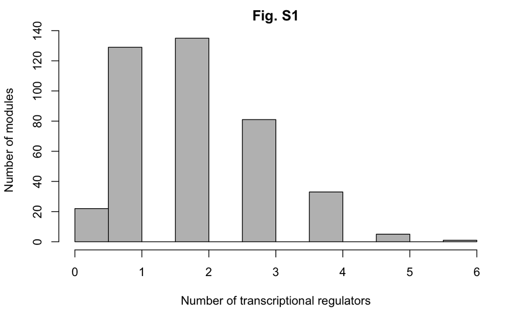

```r
#gene modules in-degree distribution
hist(c(rep(0,22),table(tf.module.table[,"Module"])),breaks=14,xlab="Number of transcriptional regulators",ylab="Number of modules",main="Fig. S1",col="grey")
```

2.3 Fig. 1B-C-D

```r
print(paste("There are",length(which(cdiff.module.residues[,"Residual"]<= 0.55)),"modules with residual <= 0.55",sep=" "))
```

```
[1] "There are 297 modules with residual <= 0.55"
```

```r
#histogram-Fig. 1B (module size)
par(mfrow=c(2,2))
h1<-hist(cdiff.module.residues$Residual[which(cdiff.module.residues$Residual <=0.55)],breaks = 20,plot = F)
h2<-hist(cdiff.module.residues$Residual[which(cdiff.module.residues$Residual > 0.55)],breaks = 20,plot = F)
plot( h1, col=rgb(0,0,1,1/4), xlim=c(0.1,1),xlab="Residual",cex.lab=1.5,cex.axis=1.5,main="Fig. 1B")
plot( h2, col=rgb(1,0,0,1/4), xlim=c(0.1,1), add=T,cex.lab=1.5,cex.axis=1.5)
```

```r
#Fig. 1C
hist(cdiff.module.residues[which(cdiff.module.residues$Residual <=0.55),"X..Genes"],
     breaks=20,xlab="Gene count", col=rgb(0,0,1,1/4),cex.lab=1.5,cex.axis=1.5, main="Fig. 1C")
#Fig. 1D
#genome and TF coverage
#without residual threshold
ranked.module.residuals<-cdiff.module.residues$Residual
ranked.module.residuals<-ranked.module.residuals[order(ranked.module.residuals,decreasing = F)]
#take into account C. difficile compiled genome annotation
genome.coverage<-c()
tf.coverage<-c()
metabolic.coverage<-c()
for(r in 1:length(ranked.module.residuals))
{
  selected.modules<-which(cdiff.module.residues$Residual <= ranked.module.residuals[r])
  temporal.genes<-c()
  for(m in selected.modules)
  {
    temporal.genes<-c(temporal.genes,cdiff.biclusters.list[[m]])
  }
  genome.coverage<-c(genome.coverage,length(intersect(temporal.genes,unique(cdiff.genome.annotation$locus_tag))))
  tf.coverage<-c(tf.coverage,length(intersect(temporal.genes,cdiff.tfs)))
  metabolic.coverage<-c(metabolic.coverage,length(intersect(temporal.genes,cdiff.metabolic.genes)))
}
plot(y=100*genome.coverage/4018,ylim=c(0,100),x=ranked.module.residuals,ylab="Coverage (%)",
     xlab="Residual",pch=0,cex.lab=1.5,cex.axis=1.5,type="o",col="darkgreen",main="Fig. 1D")
```

```r
points(y=100*tf.coverage/length(cdiff.tfs),ylim=c(0,100),x=ranked.module.residuals,
      pch=1,cex.lab=1.5,cex.axis=1.5,type="o",col="orange")
points(y=100*metabolic.coverage/length(cdiff.metabolic.genes),ylim=c(0,100),x=ranked.module.residuals,
      pch=2,cex.lab=1.5,cex.axis=1.5,type="o",col="purple")
```

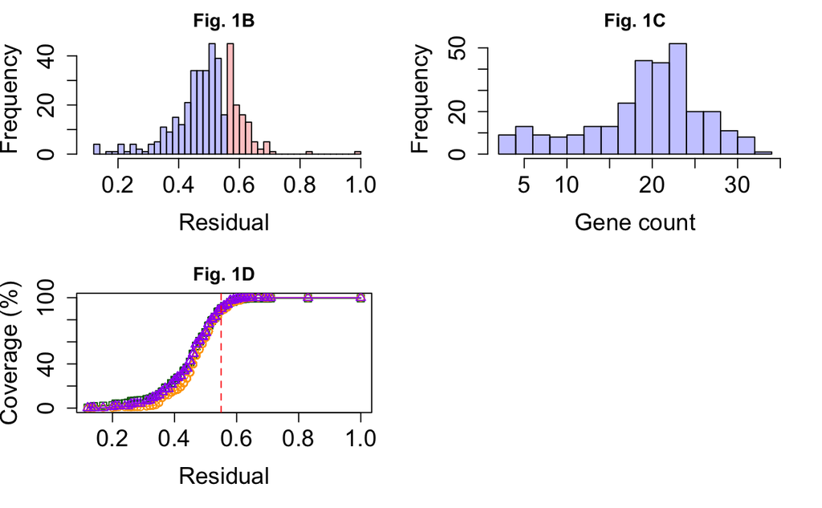

```r
abline(v=0.55,col="red",lty=2)
```

```r
#compute genome coverage by high quality modules
genes.in.high.quality.modules<-c()
for(r in 1:nrow(cdiff.module.residues))
{
  current.module<-cdiff.module.residues$Cluster[r]
  current.module.size<-cdiff.module.residues$X..Genes[r]
  current.residual<-cdiff.module.residues$Residual[r]
  if(current.residual <= 0.55)
  {
    genes.in.high.quality.modules<-union(genes.in.high.quality.modules,cdiff.biclusters.list[[current.module]])
  }
}
cdiff.genome.genes<-unique(c(as.character(cdiff.CDS),as.character(cdiff.tRNAs),as.character(cdiff.rRNAs)))
high.quality.modules.genome.coverage<-length(intersect(genes.in.high.quality.modules,cdiff.genome.genes))/length(cdiff.genome.genes)
print(paste("Genome coverage by high quality modules:", round(high.quality.modules.genome.coverage,digits=2),sep=""))
```

```
[1] "Genome coverage by high quality modules:0.9"
```

3.1 Function to analyze enrichment of EGRIN modules with a user-specified set of genes

```r
#default overlap.threshold is five
#default adjusted p-value threshold is 0.05
#biclusters are the same gene modules
evaluate.bicluster.enrichment<-function(biclusters,gene.set,overlap.threshold,adj.p.val.threshold)
{
  biclusters.enrichment = matrix(nrow=length(biclusters),ncol=5,dimnames = list(names(biclusters),c('q','m','n','k','p.value')))
  for(x in 1:length(biclusters)) {
    #overlap
    q = length(intersect(biclusters[[x]],gene.set))
    #total possible successes
    m = length(biclusters[[x]])
    #sample size (corrected by the genes in EGRIN model)
    k = length(intersect(gene.set,unique(cdiff.egrin.genes)))
    #rest of the universe
    n = length(cdiff.egrin.genes)-m
    #default p-value
    pv = NA
    #if there is overlap between the gene set and the current bicluster, the hypergeometric test is performed
    if(q > 0) {
      pv = phyper(q-1,m,n,k,lower.tail=F)
    }
    #save vector in the matrix
    biclusters.enrichment[x,] = c(q,m,n,k,pv)
  }
  #add column with Benjamini-Hochberg adjusted p-values
  biclusters.enrichment = cbind(biclusters.enrichment,p.value.BH=p.adjust(biclusters.enrichment[,'p.value'],method='BH',n=nrow(biclusters.enrichment)))
  #select enriched modules using specified thresholds
  final.enriched.modules = rownames(biclusters.enrichment)[which(biclusters.enrichment[,'p.value.BH']<=adj.p.val.threshold &  biclusters.enrichment[,'q']>=overlap.threshold)]
  output<-cbind(final.enriched.modules,rbind(biclusters.enrichment[final.enriched.modules,c("q","p.value","p.value.BH")],c()))
  colnames(output)<-c("Module","Overlap","P-value","Adj. P-value")
  output
}
#to run the function using the user-specified set of genes and default thresholds use the line below
#enriched.modules<-evaluate.bicluster.enrichment(biclusters = cdiff.biclusters.list,gene.set,overlap.threshold = 5, adj.p.val.threshold = 0.05)
```

3.2 Fig. 2A

```r
#upload expert annotation of C. difficile genome
cd630.girinathan.annotation<-read.csv("../Data/Cdifficile_genome/cd630_girinathan_annotation.csv")
#remove "N/A" values
cd630.girinathan.annotation<-cd630.girinathan.annotation[-1*which(cd630.girinathan.annotation[,1]=="N/A"),]
#create vector with function categories
function.terms<-unique(cd630.girinathan.annotation$Pathway1)
#define modules that were enriched with functional categories
enrichment.modules.functional.terms<-c()
for(a in function.terms[-7]) #remove empty entry
{
  genes.associated.with.current.term<-unique(cd630.girinathan.annotation$CD630_locus_tag[which(cd630.girinathan.annotation$Pathway1 == a)])
  modules.enriched.with.term<-evaluate.bicluster.enrichment(cdiff.biclusters.list,genes.associated.with.current.term,5,0.05)
  if(nrow(modules.enriched.with.term)>0)
{
    enrichment.modules.functional.terms<-rbind(enrichment.modules.functional.terms,                                                    cbind(as.numeric(modules.enriched.with.term[,"Module"]),rep(a,nrow(modules.enriched.with.term)),cdiff.module.residues[as.numeric(modules.enriched.with.term[,"Module"]),"Residual"]))
 }
}
colnames(enrichment.modules.functional.terms)<-c("Module", "Functional.Term","Residual")
#filter out low quality (residual > 0.55) modules
enrichment.high.quality.modules.functional.terms<-enrichment.modules.functional.terms[which(enrichment.modules.functional.terms[,"Residual"]<=0.55),]
#count how many high quality modules are enriched with at least one functional term
length(unique(enrichment.high.quality.modules.functional.terms[,"Module"]))
```

```
[1] 93
```

```r
#count how many functional terms are enriched in one or more high quality modules
length(unique(enrichment.high.quality.modules.functional.terms[,"Functional.Term"]))
```

```
[1] 45
```

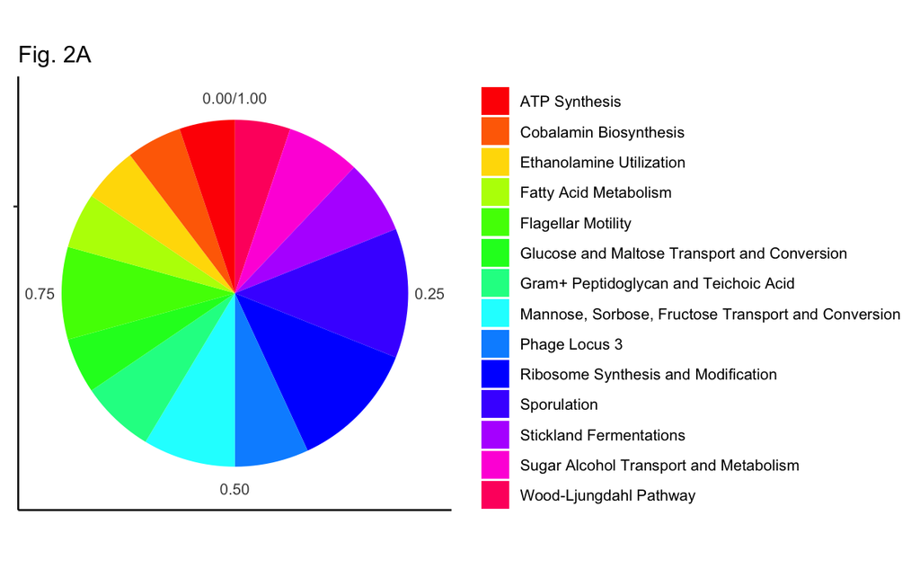

```r
#add column with short version of function term
simplified.function.terms<-c()
for(r in 1:nrow(enrichment.high.quality.modules.functional.terms))
{
  current.term<-as.character(enrichment.high.quality.modules.functional.terms[r,"Functional.Term"])
  if(length(grep("|",current.term,fixed=T))>0)
  {
  simplified.function.terms<-c(simplified.function.terms,strsplit(current.term,split = "|",fixed = T)[[1]][2])
  }
  else
  {
    simplified.function.terms<-c(simplified.function.terms,current.term)
  }
}
enrichment.high.quality.modules.functional.terms<-cbind(enrichment.high.quality.modules.functional.terms[,c(1,2)],simplified.function.terms)
#create data frame for pie chart figure
functional.term.counts<-as.data.frame(table(simplified.function.terms))
#only include terms over-represented in three or more high quality modules
functional.term.counts.three.or.higher<-functional.term.counts[which(functional.term.counts$Freq>2),]
#compute proportions
functional.term.counts.three.or.higher[,2]<-functional.term.counts.three.or.higher[,2]/sum(functional.term.counts.three.or.higher[,2])
colnames(functional.term.counts.three.or.higher)<-c("Term","Proportion")
#create piechart-
#code inspired from https://www.displayr.com/how-to-make-a-pie-chart-in-r/
pie.chart = ggplot(functional.term.counts.three.or.higher, aes(x="", y=Proportion, fill=Term)) + geom_bar(stat="identity", width=1)
#change to polar coordinates
pie.chart = pie.chart + coord_polar("y", start=0)
#specify piechart color palette and delete axes labels
pie.chart = pie.chart + scale_fill_manual(values=rainbow(nrow(functional.term.counts.three.or.higher)))+labs(x = NULL, y = NULL, fill = NULL)+theme_classic()+ ggtitle("Fig. 2A")
pie.chart
```

3.3 Fig. 2B

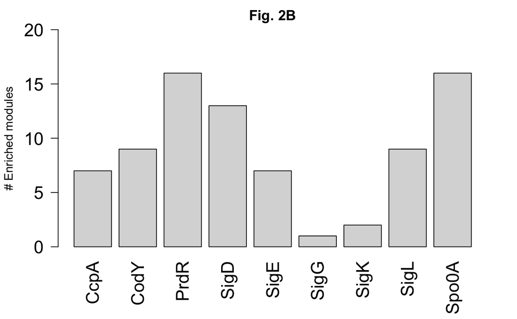

```r
#read compiled TF regulons (listed in Table 1)
TF.regulons.compilation<-read.csv("../Data/Inferelator/Input/cdiff_trn_table1.csv",header=T)
#remove any repeated rows
TF.regulons.compilation<-unique.matrix(TF.regulons.compilation)
#save TF names
TF.regulons<-unique(TF.regulons.compilation$TF)
#count regulon size (shown in Table S1)
TF.regulon.size<-table(TF.regulons.compilation[,"TF"])[TF.regulons]
#associate TF name with corresponding locus tag
tfs.loci.tags<-c("CD630_12750","CD630_12870","CD630_32450","CD630_00110","CD630_02660", "CD630_00570","CD630_12140",
                 "CD630_10640","CD630_31760","CD630_07720","CD630_26430","CD630_26420","CD630_12300")
names(tfs.loci.tags)<-TF.regulons
#evaluate over-representation of EGRIN modules with the compiled TF regulons
enrichment.modules.with.tf.regulons<-c()
for(tf in TF.regulons)
{
  tf.regulon<-TF.regulons.compilation[which(TF.regulons.compilation[,"TF"]==tf),"Target"]
  modules.enriched.with.TF.regulon<-evaluate.bicluster.enrichment(cdiff.biclusters.list,tf.regulon,overlap.threshold = 5,adj.p.val.threshold = 0.05)
  if(nrow(modules.enriched.with.TF.regulon)>0)
  {
    enrichment.modules.with.tf.regulons<-rbind(enrichment.modules.with.tf.regulons,cbind(rep(tf,nrow(modules.enriched.with.TF.regulon)),modules.enriched.with.TF.regulon,cdiff.module.residues[as.numeric(modules.enriched.with.TF.regulon[,"Module"]),"Residual"]))
  }
}
#add column names
colnames(enrichment.modules.with.tf.regulons)<-c("TF","Module","Overlap","P.value","Adj. P.value","Residual")
#select high quality modules that were enriched with TF regulons
high.quality.modules.enriched.with.TF.regulons<-enrichment.modules.with.tf.regulons[which(enrichment.modules.with.tf.regulons[,"Residual"]<= 0.55),]
#count number of times each TF regulon is over-represented in the subset of high quality modules
count.regulons.overrepresentation<-table(high.quality.modules.enriched.with.TF.regulons[,"TF"])
#define color palette for Fig. 2B
colors.fig2B<-colorRampPalette(rev(brewer.pal(9, "Set3")) )(9)
barplot(t(as.matrix(count.regulons.overrepresentation)),las=2,ylab="# Enriched modules",cex.axis = 1.5,
        cex.names = 1.5,ylim=c(0,20),col = colors.fig2B, main="Fig. 2B" )
```

```r
#check the recall of known TF-gene interactions in the modules that were enriched with TF regulons
over.represented.tfs<-unique(high.quality.modules.enriched.with.TF.regulons[,"TF"])
#count the total set of TF-gene interactions involving over-represented TF regulons
total.interactions.over.represented.tfs<-length(which(TF.regulons.compilation[,"TF"] %in% over.represented.tfs))
#define the subset of interactions that were recovered in the modules enriched with TF regulons
recalled.interactions<-c()
for(i in 1:nrow(high.quality.modules.enriched.with.TF.regulons))
{
  current.module.id<-as.numeric(high.quality.modules.enriched.with.TF.regulons[i,"Module"])
  current.module<-cdiff.biclusters.list[[current.module.id]]
  current.tf<-high.quality.modules.enriched.with.TF.regulons[i,"TF"]
  current.regulon<-TF.regulons.compilation[which(TF.regulons.compilation[,"TF"]==current.tf),"Target"]
  recovered.interactions<-intersect(current.module,current.regulon)
  if(length(recovered.interactions)>0)
  {
  recalled.interactions<-rbind(recalled.interactions,cbind(rep(current.tf,length(recovered.interactions)),recovered.interactions))
  }
}
#estimate recall rate
nrow(unique.matrix(recalled.interactions))/total.interactions.over.represented.tfs
```

```
[1] 0.4254967
```

```r
#identify the modules enriched with more than one TF regulon
temporal.module.regulon.count<-table(high.quality.modules.enriched.with.TF.regulons[,"Module"])
modules.enriched.with.more.than.one.regulon<-names(which(temporal.module.regulon.count >1))
print(paste("There are",length(modules.enriched.with.more.than.one.regulon), "high quality modules enriched with more than one TF regulon",sep=" "))
```

```
[1] "There are 19 high quality modules enriched with more than one TF regulon"
```

```r
enrichment.modules.enriched.with.more.than.one.regulon<-high.quality.modules.enriched.with.TF.regulons[which(high.quality.modules.enriched.with.TF.regulons[,"Module"] %in% modules.enriched.with.more.than.one.regulon),]
#count total genes associated with modules enriched with the Spo0A regulon and one more TF regulon
genes.in.modules.associated.with.spo0A<-c()
spo0A.associated.modules<-as.numeric(enrichment.modules.enriched.with.more.than.one.regulon[which(enrichment.modules.enriched.with.more.than.one.regulon[,"TF"]=="Spo0A"),"Module"])
spo0A.associated.modules<-unique(spo0A.associated.modules)
for(m in spo0A.associated.modules)
{
  genes.in.modules.associated.with.spo0A<-union(genes.in.modules.associated.with.spo0A,cdiff.biclusters.list[[m]])
}
print(length(genes.in.modules.associated.with.spo0A))
```

```
[1] 161
```

3.4 Fig. 2G

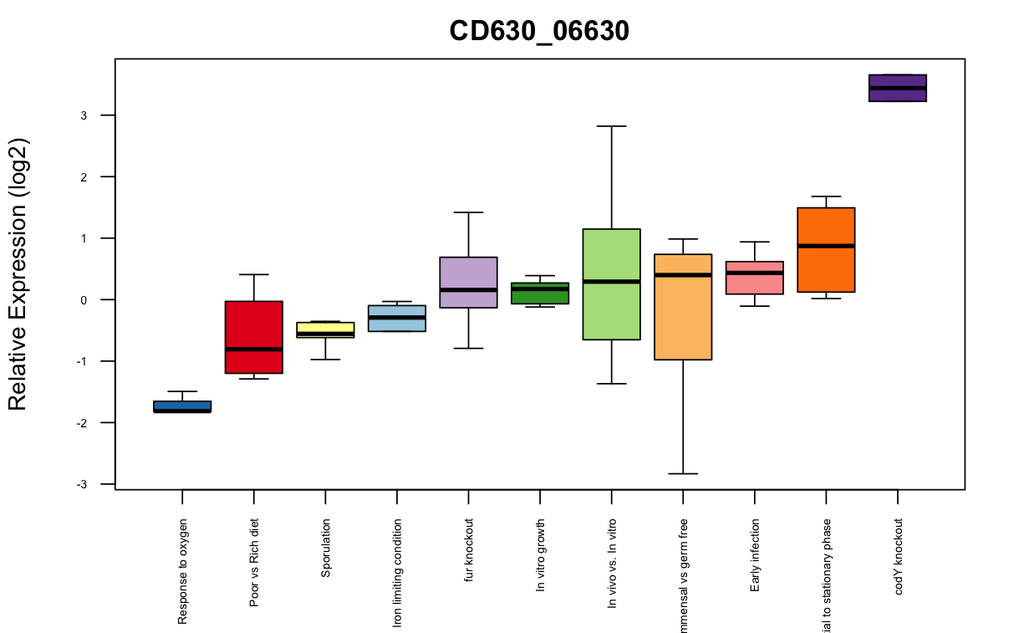

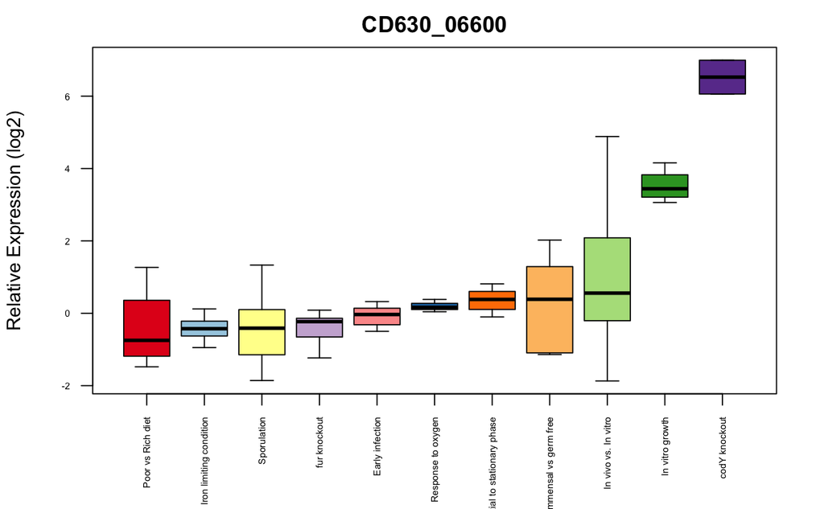

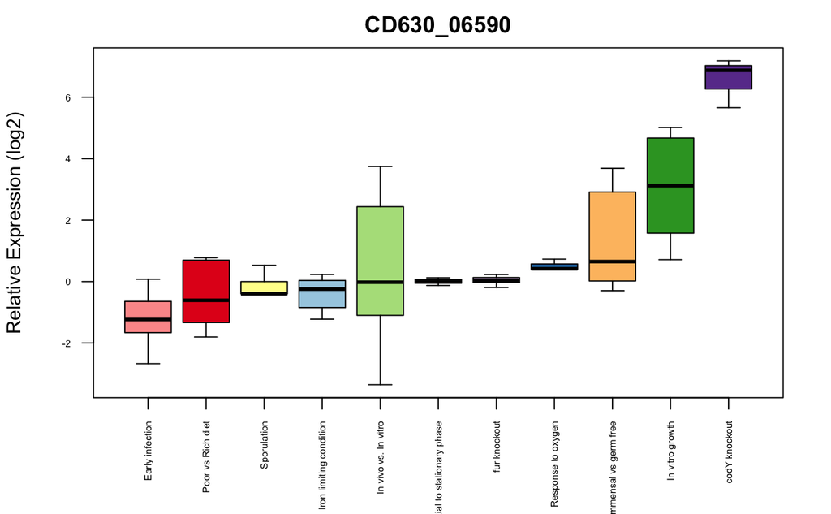

```r
#read conditional block information
transcriptome.metadata<-read.csv("../Data/EGRIN/Input/metadata_transcriptional_compendium.csv",header=T)
#define conditional blocks
conditional.blocks<-unique(transcriptome.metadata[,2])
#fix minor changes introduced when reading the .csv file
transcriptome.metadata[,1]<-gsub(".vs. ",".vs..",transcriptome.metadata[,1])
#define color palette for the boxplot
boxplot.colors<-rainbow(length(conditional.blocks))
boxplot.colors<-brewer.pal(11,"Paired")
names(boxplot.colors)<-conditional.blocks
#plot expresion pattern of tcdA, tcdB and tcdR
paloc.genes<-c("CD630_06630","CD630_06600","CD630_06590")
for(g in paloc.genes)
{
#vector to save the log2 ratio values for each conditional block
expression.by.condition<-vector(mode = "list", length = length(conditional.blocks))
names(expression.by.condition)<-conditional.blocks
#compute median log2 ratio for each conditional block
median.expression.per.condition<-c()
for(c in 1:length(conditional.blocks))
{
  temporal.vector<-as.vector(transcriptomes[g,which(transcriptome.metadata[,2]==names(expression.by.condition)[c])])
  #remove NA values
  expression.by.condition[[c]]<- temporal.vector[!is.na(temporal.vector)]
  #compute and save median
  median.expression.per.condition<-c(median.expression.per.condition,median(expression.by.condition[[c]]))
}
#order the median values
ordered.conditional.blocks<-order(median.expression.per.condition,decreasing = F)
#create boxplot
boxplot(expression.by.condition[ordered.conditional.blocks],names=names(expression.by.condition)[ordered.conditional.blocks],
        ylab="Relative Expression (log2)",outline=F,las=2,whisklty=1,col=boxplot.colors[ordered.conditional.blocks],main=g,cex=0.5,yex=0.5,cex.axis=0.5)
}
```

4. Generating hypotheses for uncharacterized genes 4.1 Identifying modules enriched with uncharacterized genes- Fig. 3A

```r
#functional term enrichment analysis
#we focus on modules with  >45% of genes in the enriched process
#remove phage-related terms from Girinathan et al. annotation
function.terms.no.phage<-function.terms[-1*grep("Phage Locus",function.terms)]
function.terms.no.phage<-function.terms.no.phage[-7]
#define list of genes associated with a function term (to identify uncharacterized genes)
cdiff.annotated.genes.in.girinathan<-c()
for(t in function.terms.no.phage)
{
  cdiff.annotated.genes.in.girinathan<-union(cdiff.annotated.genes.in.girinathan,cd630.girinathan.annotation[which(cd630.girinathan.annotation[,"Pathway1"]==t),"CD630_locus_tag"])
}
#evaluate functional enrichment of EGRIN modules
#list with unknown genes associated with each function term due to "guilt by association"
unknown.genes.associated.with.terms<-vector(mode = "list", length = length(function.terms.no.phage))
names(unknown.genes.associated.with.terms)<-function.terms.no.phage
#list with modules that contain unknown genes associated with function terms due to "guilt by association"
modules.associated.with.terms<-vector(mode = "list", length = length(function.terms.no.phage))
names(modules.associated.with.terms)<-function.terms.no.phage
#vector with set of unknow genes with hypotheses about their functional role
unknown.genes.with.hypotheses<-c()
for(t in function.terms.no.phage)
{
  current.term<-unique(cd630.girinathan.annotation$CD630_locus_tag[which(cd630.girinathan.annotation$Pathway1 == t)])
  temporal.enriched.module<-evaluate.bicluster.enrichment(cdiff.biclusters.list,current.term,overlap.threshold = 5,adj.p.val.threshold = 0.05)
  if(nrow(temporal.enriched.module)>0)
  {
    for(m in 1:nrow(temporal.enriched.module))
    {
      current.module<-as.numeric(temporal.enriched.module[m,"Module"])
      current.module.residue<-as.numeric(cdiff.module.residues[which(cdiff.module.residues$Cluster==current.module),"Residual"])
      #uncharacterized genes are defined using both C. difficile annotations
      unknown.genes.in.module<-setdiff(intersect(cdiff.unknown.genes,cdiff.biclusters.list[[current.module]]),cdiff.annotated.genes.in.girinathan)
      #apply the 45% threshold (i.e., 45% of annotated genes in the high quality module belong to the current functional term)
      if((as.numeric(temporal.enriched.module[m,"Overlap"])/(length(cdiff.biclusters.list[[current.module]])-length(unknown.genes.in.module)))>0.45 & length(unknown.genes.in.module)>0 & current.module.residue < 0.56)
      {
        unknown.genes.associated.with.terms[[t]]<-union(unknown.genes.associated.with.terms[[t]],unknown.genes.in.module)
        modules.associated.with.terms[[t]]<-union(modules.associated.with.terms[[t]],current.module)
        unknown.genes.with.hypotheses<-union(unknown.genes.with.hypotheses,unknown.genes.in.module)
      }
    }
      }
}
print(length(unknown.genes.with.hypotheses))
```

```
[1] 48
```

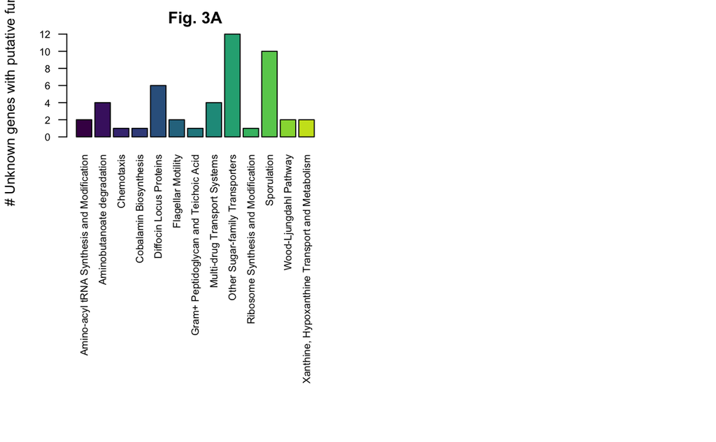

```r
#filter out function terms without gene with hypotheses
terms.with.new.putative.genes<-c()
total.additions.per.function.term<-c()
for(n in 1:length(unknown.genes.associated.with.terms))
{
  if(!is.null(unknown.genes.associated.with.terms[[n]]))
  {
    terms.with.new.putative.genes<-c(terms.with.new.putative.genes,names(unknown.genes.associated.with.terms)[n])
    total.additions.per.function.term<-c(total.additions.per.function.term,length(unknown.genes.associated.with.terms[[n]]))
  }
}
#edit function term names
terms.with.new.putative.genes<-sapply(1:length(terms.with.new.putative.genes),
                             function(x){strsplit(terms.with.new.putative.genes[x],split = "|",fixed=T)[[1]][2]})
names(total.additions.per.function.term)<-terms.with.new.putative.genes
#generate barplot (Fig. 3A)
par(mfrow=c(2,2))
barplot(total.additions.per.function.term[order(terms.with.new.putative.genes)],
        names=terms.with.new.putative.genes[order(terms.with.new.putative.genes)],
        las=2,col=viridis(14),ylab="# Unknown genes with putative function",srt= 45,main="Fig. 3A",cex=0.75,cex.axis=0.75)
```

4.2 Fig.3B

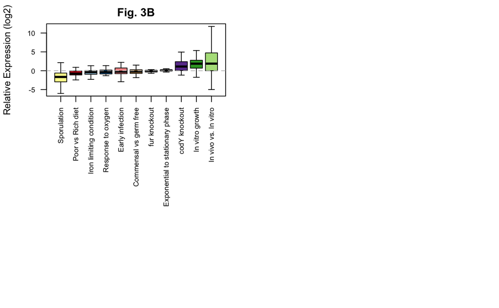

```r
#select unknown genes associated with sporulation
putative.sporulation.genes<-unknown.genes.associated.with.terms$`1.8.1.100|Sporulation`
#list to save the expression values of the selected genes in each conditional block
putative.sporulation.genes.expression.by.condition<-vector(mode = "list", length = length(conditional.blocks))
names(putative.sporulation.genes.expression.by.condition)<-conditional.blocks
putative.sporulation.genes.average.expression.by.condition<-c()
for(c in 1:length(conditional.blocks))
{
  temporal.vector<-as.vector(transcriptomes[putative.sporulation.genes,which(transcriptome.metadata[,2]==names(putative.sporulation.genes.expression.by.condition)[c])])
  #remove NA values and save in list
  putative.sporulation.genes.expression.by.condition[[c]]<-temporal.vector[!is.na(temporal.vector)]
  #compute median of expression by condition
  putative.sporulation.genes.average.expression.by.condition<-c(putative.sporulation.genes.average.expression.by.condition,median(putative.sporulation.genes.expression.by.condition[[c]]))
}
#order  median expression values
ordered.conditional.blocks<-order( putative.sporulation.genes.average.expression.by.condition,decreasing = F)
par(mfrow=c(2,2))
boxplot(putative.sporulation.genes.expression.by.condition[ordered.conditional.blocks],names=names(putative.sporulation.genes.expression.by.condition)[ordered.conditional.blocks],
        ylab="Relative Expression (log2)",outline=F,las=2,whisklty=1,col=boxplot.colors[ordered.conditional.blocks], main="Fig. 3B",cex=0.75,cex.axis=0.75)
abline(h=0,col="grey",lty=2)
```

4.3 Table S4 - Description of unknown genes with putative function

```r
table.s4<-c()
for(t in terms.with.new.putative.genes)
{
  genes.associated.with.current.term<-unknown.genes.associated.with.terms[[grep(t,names(unknown.genes.associated.with.terms),fixed=T)]]
  genes.associated.with.current.term<-genes.associated.with.current.term[order(genes.associated.with.current.term)]
  modules.containing.genes.associated.with.current.term<-modules.associated.with.terms[[grep(t,names(modules.associated.with.terms),fixed=T)]]
  table.s4<-rbind(table.s4,cbind(as.character(t),paste(modules.containing.genes.associated.with.current.term,collapse=";"),paste(genes.associated.with.current.term,collapse=";"),length(genes.associated.with.current.term)))
}
#add column names
colnames(table.s4)<-c("Function Term","Enriched Modules","Uncharacterized genes", "# genes")
#print table
print(table.s4)
```

```
      Function Term                                     Enriched Modules
 [1,] "Sporulation"                                     "206;251"
 [2,] "Amino-acyl tRNA Synthesis and Modification"      "333"
 [3,] "Ribosome Synthesis and Modification"             "317"
 [4,] "Cobalamin Biosynthesis"                          "157"
 [5,] "Gram+ Peptidoglycan and Teichoic Acid"           "121"
 [6,] "Multi-drug Transport Systems"                    "29"
 [7,] "Diffocin Locus Proteins"                         "136"
 [8,] "Wood-Ljungdahl Pathway"                          "159;168"
 [9,] "Aminobutanoate degradation"                      "48"
[10,] "Xanthine, Hypoxanthine Transport and Metabolism" "145"
[11,] "Flagellar Motility"                              "296"
[12,] "Other Sugar-family Transporters"                 "43"
[13,] "Chemotaxis"                                      "342"
      Uncharacterized genes
```

[output cut: 27 more lines]

5.1 Enrichment analysis of quintiles by conditions - Related to Supp. file S1

```r
#perform hypergeometric test for the quintiles for each bicluster
#there are 406 modules in the Cdiff EGRIN model
module.selection<-1:406
#exclude from downstream analysis three modules that contain conditions in which all genes were NAs
module.selection<-module.selection[-1*c(33,74,101)]
#add rownames to the transcriptome metadata matrix
rownames(transcriptome.metadata)<-transcriptome.metadata[,1]
#save modules up-regulated and over-represented (highest quintile) with condition blocks
blocks.over.representation.table<-c()
#loop for each module
for(module in module.selection)
{
  #genes in each module
  current.module<-cdiff.biclusters.list[[module]]
  #if the module contains more than one gene
  if(length(current.module)>1)
  {
    #differential treatment for module 353 and onwards due to one extra module in the cdiff.condition.clusters.list
    if(module <= 352)
    {
    #conditions associated with the current module
    module.conditions<-cdiff.condition.clusters.list[[module]]
    }
    if(module > 352)
    {
    #conditions associated with the current module
    module.conditions<-cdiff.condition.clusters.list[[module+1]]
    }
    #this edit is necessary to fix some discrepancies in the condition names
    temporal.conditions<-gsub(".vs. ",".vs..",module.conditions)
    #confirm that all discrepancies in the condition names were resolved
    if(length(intersect(temporal.conditions,colnames(transcriptomes)))/length(temporal.conditions) != 1)
    {
      print("Error")
    }
    #create matrix with the expression profiles of all genes in the current module and relevant conditions
    module.expression.matrix<-transcriptomes[as.character(current.module),as.character(temporal.conditions)]
    #compute the median value per column - NA values are not considered
    matrix.median<-apply(FUN=median,MARGIN=2,module.expression.matrix,na.rm=T)
    #define the quintiles (i.e, 0%-20%, 21%-40%, 41%-60%, 61%-80%, 81%-100%)
    quintiles<-quantile(matrix.median,seq(0,1,by=0.2))
    #create matrix with the p-values of the enrichment tests
    quintile.enrichment.matrix<-matrix(ncol=5,nrow=11,0,dimnames = list(conditional.blocks,c("20%","40%","60%","80%","100%")))
    #define conditions included in the module
    full.samples.conditions<-transcriptome.metadata[colnames(module.expression.matrix),"Condition"]
    #assign conditions to each quintile and perform enrichment tests
      for(j in 2:length(quintiles))
    {
      #the 1st quintile
        current.quintile.average.expression<-c()
        if(j==2)
      {
        #extract sample IDs
        exp.samples<-names(matrix.median)[which(matrix.median <= quintiles[j])]
        #define the conditions associated with the corresponding samples
        conditions<-as.character(transcriptome.metadata[as.character(exp.samples),"Condition"])
        #compute average expression across conditions in current quintile
        current.quintile.average.expression<-mean(module.expression.matrix[,as.character(exp.samples)],na.rm=T)
      }
        #for the other quintiles
        else
      {
        #extract sample IDs
        exp.samples<-names(matrix.median)[which(matrix.median <= quintiles[j] & matrix.median > quintiles[j-1])]
        #define the conditions associated with the corresponding samples
        conditions<-as.character(transcriptome.metadata[exp.samples,"Condition"])
        #compute average expression across conditions in current quintile
        current.quintile.average.expression<-mean(module.expression.matrix[,as.character(exp.samples)],na.rm=T)
      }
      #loop to perform hypergeometric test for each condition block
      for(b in conditional.blocks)
      {
        #if there is actual overlap between the conditions in the quintile and the current condition
        if(length(which(conditions==b))>0)
        {
          #hypergeometric test
          temporal.pvalue<-phyper(length(which(conditions == b))-1,length(which(full.samples.conditions==b)),length(matrix.median)-length(which(full.samples.conditions==b)),length(conditions),lower.tail = F)
          #save output in matrix
          quintile.enrichment.matrix[b,j-1]<- -log10(temporal.pvalue)
          #check for enrichment and downregulation in the 1st quintile
          if(temporal.pvalue <= 0.001 & j==2 & current.quintile.average.expression< -1)
          {
            blocks.over.representation.table<-rbind(blocks.over.representation.table,
                                                    cbind(module,b,"20%","Lowest"))
          }
          #check for enrichment and downregulation in the 1st quintile
          if(temporal.pvalue <= 0.001 & j==6 & current.quintile.average.expression > 1)
          {
            blocks.over.representation.table<-rbind(blocks.over.representation.table,
                                                    cbind(module,b,"100%","Highest"))
          }
          }
      }
      }
      #write csv file
    #write.csv(file=paste("../cMonkey2_output/enrichment_condition_blocks_1105/conditionEnrichment",module,".csv",sep=""),quintile.enrichment.matrix)
  }
}
colnames(blocks.over.representation.table)<-c("Module","Condition","Quintile","Profile")
#write.csv(file="../cMonkey2_output/enrichment_condition_blocks_1105/conditions_over_represented_highest_lowest_quintiles.csv",blocks.over.representation.table,row.names = F)
```

5.2 Count modules and corresponding genes that are up- or down-regulated for “in vivo vs. in vitro” and “Early infection”

```r
#save upregulated modules and  enriched with 'In vivo vs. In vitro' condition in the 5th quintile
modules.up.invivo<-unique(as.numeric(blocks.over.representation.table[which(blocks.over.representation.table[,"Condition"]=="In vivo vs. In vitro" & blocks.over.representation.table[,"Profile"]=="Highest"),"Module"]))
#save the corresponding upregulated genes
genes.up.invivo<-c()
for(m in modules.up.invivo)
{
  genes.up.invivo<-union(genes.up.invivo,cdiff.biclusters.list[[m]])
}
print(paste("There are",length(genes.up.invivo),"genes across",length(modules.up.invivo), "modules enriched with *In vivo vs In vitro* samples in the 5th quintile (highest expression)",sep=" "))
```

```
[1] "There are 680 genes across 43 modules enriched with *In vivo vs In vitro* samples in the 5th quintile (highest expression)"
```

```r
#similar approach for downregulated modules that are  enriched with 'In vivo vs. In vitro' condition in the 1st quintile
modules.down.invivo<-unique(as.numeric(blocks.over.representation.table[which(blocks.over.representation.table[,"Condition"]=="In vivo vs. In vitro" & blocks.over.representation.table[,"Profile"]=="Lowest"),"Module"]))
#save downregulated genes
genes.down.invivo<-c()
for(m in modules.down.invivo)
{
  genes.down.invivo<-union(genes.down.invivo,cdiff.biclusters.list[[m]])
}
print(paste("There are",length(genes.down.invivo),"genes across",length(modules.down.invivo), "modules enriched with *In vivo vs In vitro* samples in the 1st quintile (lowest expression)",sep=" "))
```

```
[1] "There are 1325 genes across 82 modules enriched with *In vivo vs In vitro* samples in the 1st quintile (lowest expression)"
```

```r
#same approach for the 'Early infection' condition
modules.associated.with.early.infection<-unique(as.numeric(blocks.over.representation.table[which(blocks.over.representation.table[,"Condition"]=="Early infection"),"Module"]))
genes.associated.with.early.infection<-c()
for(m in modules.associated.with.early.infection)
{
  genes.associated.with.early.infection<-union(genes.associated.with.early.infection,cdiff.biclusters.list[[m]])
}
print(paste("There are",length(modules.associated.with.early.infection), "modules enriched with *Early Infection* samples in the 1st and 5th quintiles (lowest and highest expression, respectively)",sep=" "))
```

```
[1] "There are 3 modules enriched with *Early Infection* samples in the 1st and 5th quintiles (lowest and highest expression, respectively)"
```

6. Analysis of transcriptional response of C. difficile in in vivo contexts in the presence of commensals 6.1 Fig. 4C

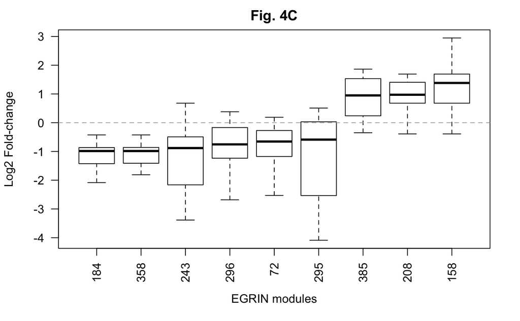

```r
#read output of differential expression analysis for mono-colonized mice - CD24h vs CD20h (Girinathan et al. 2020)
monocolonized.20h.vs.24h<-read.csv("../Data/Girinathan_transcriptomes/cd_24h_vs_20h.csv")
#differentially expressed genes (DEGs), up-regulated subset
DEGs.up<-monocolonized.20h.vs.24h$CD630_locus_tag[which(monocolonized.20h.vs.24h$log2FoldChange > 1 & monocolonized.20h.vs.24h$padj < 0.05)]
#remove duplicates
DEGs.up<-unique(DEGs.up)
#remove N/A values
DEGs.up<-DEGs.up[-10]
#differentially expressed genes (DEGs), down-regulated subset
DEGs.down<-monocolonized.20h.vs.24h$CD630_locus_tag[which(monocolonized.20h.vs.24h$log2FoldChange < -1 & monocolonized.20h.vs.24h$padj < 0.05)]
#remove duplicates
DEGs.down<-unique(DEGs.down)
#remove N/A values
DEGs.down<-DEGs.down[-11]
#identify EGRIN modules enriched with upregulated genes
enriched.biclusters.cd24vs20.up<-evaluate.bicluster.enrichment(cdiff.biclusters.list,DEGs.up,overlap.threshold = 5, adj.p.val.threshold = 0.05)
#identify EGRIN modules enriched with downregulated genes
enriched.biclusters.cd24vs20.down<-evaluate.bicluster.enrichment(cdiff.biclusters.list,DEGs.down,overlap.threshold = 5,adj.p.val.threshold = 0.05)
#consolidate all modules enriched with DEGs
monocolonized.diff.exp.modules.cd24vs20<-c(rownames(enriched.biclusters.cd24vs20.up),rownames(enriched.biclusters.cd24vs20.down))
#evaluate functional enrichment of these modules
functional.enrichment.cd20vscd24.modules<-c()
for(t in function.terms[-7])
{
  genes.associated.with.current.term<-as.character(cd630.girinathan.annotation$CD630_locus_tag[which(cd630.girinathan.annotation$Pathway1 == t)])
  modules.enriched.with.term<-evaluate.bicluster.enrichment(cdiff.biclusters.list,genes.associated.with.current.term,overlap.threshold = 5,adj.p.val.threshold = 0.05)
  #modules enriched with DEGs & current function term
  monocolonized.modules.diff.exp.and.enriched.with.function<-intersect(modules.enriched.with.term[,"Module"],monocolonized.diff.exp.modules.cd24vs20)
  if(length(monocolonized.modules.diff.exp.and.enriched.with.function)>0 & length(modules.enriched.with.term)>0)
  {
    functional.enrichment.cd20vscd24.modules<-rbind(functional.enrichment.cd20vscd24.modules,cbind(rep(t,length(monocolonized.modules.diff.exp.and.enriched.with.function)),monocolonized.modules.diff.exp.and.enriched.with.function))
  }
}
colnames(functional.enrichment.cd20vscd24.modules)<-c("Regulon","Module")
#evaluate enrichment with TF regulons
regulon.enrichment.cd20vscd24.modules<-c()
for(tf in TF.regulons)
{
  tf.regulon<-as.character(TF.regulons.compilation[which(TF.regulons.compilation[,1]==tf),2])
  enriched.biclusters<-evaluate.bicluster.enrichment(cdiff.biclusters.list,tf.regulon,overlap.threshold = 5,adj.p.val.threshold = 0.05)
  monocolonized.modules.diff.exp.and.enriched.with.regulon<-intersect(enriched.biclusters[,"Module"],monocolonized.diff.exp.modules.cd24vs20)
  if(length(monocolonized.modules.diff.exp.and.enriched.with.regulon)>0 & length(enriched.biclusters)>0)
  {
    regulon.enrichment.cd20vscd24.modules<-rbind(regulon.enrichment.cd20vscd24.modules,
                                                 cbind(rep(tf,length(monocolonized.modules.diff.exp.and.enriched.with.regulon)),monocolonized.modules.diff.exp.and.enriched.with.regulon))
  }
}
colnames(regulon.enrichment.cd20vscd24.modules)<-c("Regulon","Module")
#define set of modules enriched with TF regulons and/or functional terms
selected.modules.monocolonized<-union(regulon.enrichment.cd20vscd24.modules[,"Module"], functional.enrichment.cd20vscd24.modules[,"Module"])
#save median fold-change of each module
boxplot.median.changes<-c()
filtered.modules<-c()
for(m in selected.modules.monocolonized)
{
  current.module<-as.character(cdiff.biclusters.list[[m]])
  #module fold-change
  module.fc<-monocolonized.20h.vs.24h$log2FoldChange[monocolonized.20h.vs.24h$CD630_locus_tag %in% current.module]
  #filter out modules with median absolute log2 fold-change < 0.5
  if(median(module.fc)>= 0.5 | median(module.fc) <= -0.5)
  {
    filtered.modules<-c(filtered.modules,m)
    boxplot.median.changes<-c(boxplot.median.changes,median(module.fc))
  }
}
names(boxplot.median.changes)<-filtered.modules
#rank modules by median fold-change
ordered.modules<-filtered.modules[order(boxplot.median.changes,decreasing = T)]
#save values in data frame for Fig. 4C
#module names
boxplot.module<-c()
boxplot.fold.changes<-c()
for(m in ordered.modules)
{
  #genes in current module
  current.module<-as.character(cdiff.biclusters.list[[m]])
  #module fold-change
  module.fc<-monocolonized.20h.vs.24h$log2FoldChange[monocolonized.20h.vs.24h$CD630_locus_tag %in% current.module]
  boxplot.fold.changes<-c(boxplot.fold.changes,module.fc)
  boxplot.module<-c(boxplot.module,rep(m,length(module.fc)))
}
#create data frame to generate boxplot
#multiply by -1 the fold changes because the figure is CD24h vs CD20h
df.cd24.cd20<-data.frame(boxplot.module,-1*boxplot.fold.changes)
df.cd24.cd20$boxplot.module<-factor(df.cd24.cd20$boxplot.module,levels=ordered.modules)
colnames(df.cd24.cd20)<-c("Module","Fold-change")
#plot selected modules- Fig 4C (raw draft)
par(mfrow=c(1,1))
boxplot(df.cd24.cd20$`Fold-change` ~ df.cd24.cd20$Module,
        ylab="Log2 Fold-change",las=2,main="Fig. 4C",outline=F,xlab="EGRIN modules")
abline(h=0,lty=2,col="darkgrey")
```

6.2 Fig. 4F

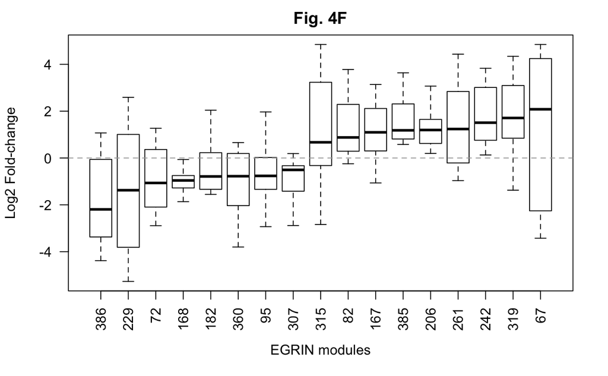

```r
#load output of differential expression analysis for CD + P. bifermentans (CD+PBI24h) vs CD + C. sardiniense (CD+CSAR24h)
csar24.vs.pbi24<-read.csv("../Data/Girinathan_transcriptomes/csar24h_vs_pbi24h.csv")
#read gene map between CD630 and ATCC strains
gene.map.atcc.cd630<-read.csv("../Data/Girinathan_transcriptomes/atcc_cd630_gene_map.csv",header=T,row.names = 1)
#add loci IDs in CD630 genome
csar24.vs.pbi24<-cbind(csar24.vs.pbi24,gene.map.atcc.cd630[as.character(csar24.vs.pbi24$Gene),"CD630_locus_tag"])
#name the fourth column
colnames(csar24.vs.pbi24)[4]<-"CD630_locus_tag"
#delete rows without locus tag
csar24.vs.pbi24<-csar24.vs.pbi24[grep("N/A",csar24.vs.pbi24$CD630_locus_tag,invert = T),]
#differentially expressed genes (DEGs), upregulated subset
DEGs.up<-csar24.vs.pbi24$CD630_locus_tag[which(csar24.vs.pbi24$log2FoldChange > 1 & csar24.vs.pbi24$padj < 0.05)]
#remove duplicates
DEGs.up<-unique(DEGs.up)
#identify modules enriched with the set of upregulated genes
enriched.biclusters.csar24.vs.pbi24.up<-evaluate.bicluster.enrichment(cdiff.biclusters.list,DEGs.up,overlap.threshold = 5,adj.p.val.threshold = 0.05)
#repeat analysis for downregulated genes
DEGs.down<-csar24.vs.pbi24$CD630_locus_tag[which(csar24.vs.pbi24$log2FoldChange < -1 & csar24.vs.pbi24$padj < 0.05)]
#remove duplicates
DEGs.down<-unique(DEGs.down)
#identify modules enriched with the set of downregulated genes
enriched.biclusters.csar24.vs.pbi24.down<-evaluate.bicluster.enrichment(cdiff.biclusters.list,DEGs.down,overlap.threshold = 5,adj.p.val.threshold = 0.05)
#consolidate names of modules enriched with differentially expressed genes
modules.csar24.vs.pbi24<-c(rownames(enriched.biclusters.csar24.vs.pbi24.down),rownames(enriched.biclusters.csar24.vs.pbi24.up))
#evaluate functional enrichment of these modules
functionally.enriched.modules.csar24.vs.pbi24<-c()
for(t in function.terms[-7])
{
  current.term.genes<-as.character(cd630.girinathan.annotation$CD630_locus_tag[which(cd630.girinathan.annotation$Pathway1 == t)])
  modules.enriched.with.term<-evaluate.bicluster.enrichment(cdiff.biclusters.list,current.term.genes,overlap.threshold = 5,adj.p.val.threshold = 0.05)
  modules.diff.exp.and.function<-intersect(modules.enriched.with.term[,"Module"],modules.csar24.vs.pbi24)
  if(length(modules.diff.exp.and.function)>0 & length(modules.enriched.with.term)>0)
  {
    functionally.enriched.modules.csar24.vs.pbi24<-rbind(functionally.enriched.modules.csar24.vs.pbi24,
                                                   cbind(rep(t,length(modules.diff.exp.and.function)),modules.diff.exp.and.function))
  }
}
colnames(functionally.enriched.modules.csar24.vs.pbi24)<-c("Regulon","Module")
#evaluate enrichment with TF regulons
diff.exp.modules.enriched.with.regulons<-c()
for(tf in TF.regulons)
{
  tf.regulon<-as.character(TF.regulons.compilation[which(TF.regulons.compilation[,1]==tf),2])
  modules.enriched.with.current.regulon<-evaluate.bicluster.enrichment(cdiff.biclusters.list,tf.regulon,overlap.threshold = 5,adj.p.val.threshold = 0.05)
   modules.diff.exp.and.regulon<-intersect(modules.enriched.with.current.regulon[,"Module"],modules.csar24.vs.pbi24)
  if(length(modules.diff.exp.and.regulon)>0 & length(modules.enriched.with.current.regulon)>0)
  {
    diff.exp.modules.enriched.with.regulons<-rbind(diff.exp.modules.enriched.with.regulons,cbind(rep(tf,length(modules.diff.exp.and.regulon)), modules.diff.exp.and.regulon))
  }
}
colnames(diff.exp.modules.enriched.with.regulons)<-c("Regulon","Module")
#define set of differentially expressed modules enriched with function term and/or regulons
selected.modules<-union(diff.exp.modules.enriched.with.regulons[,"Module"], functionally.enriched.modules.csar24.vs.pbi24[,"Module"])
#median fold-change per module
boxplot.median.changes<-c()
#modules to be considered
filtered.modules<-c()
for(m in selected.modules)
{
  current.module<-as.character(cdiff.biclusters.list[[m]])
  #module fold-change
  module.fc<-csar24.vs.pbi24$log2FoldChange[csar24.vs.pbi24$CD630_locus_tag %in% current.module]
  #filter out modules with median absolute log2 fold-change < 0.5
  if(median(module.fc)>= 0.5 | median(module.fc) <= -0.5)
  {
    filtered.modules<-c(filtered.modules,m)
    boxplot.median.changes<-c(boxplot.median.changes,median(module.fc))
  }
}
names(boxplot.median.changes)<-filtered.modules
#rank modules by median fold-change
ordered.modules<-filtered.modules[order(boxplot.median.changes,decreasing = T)]
boxplot.module<-c()
boxplot.fold.changes<-c()
for(m in ordered.modules)
{
  current.module<-as.character(cdiff.biclusters.list[[m]])
  module.fc<-csar24.vs.pbi24$log2FoldChange[csar24.vs.pbi24$CD630_locus_tag %in% current.module]
  boxplot.fold.changes<-c(boxplot.fold.changes,module.fc)
  boxplot.module<-c(boxplot.module,rep(m,length(module.fc)))
}
#save values in data frame for Fig. 4F
#multiply by -1 the fold changes because the figure is CD+PBI at 24h vs CD+CSAR at 24h
df.pbi24.csar24<-data.frame(boxplot.module,-1*boxplot.fold.changes)
df.pbi24.csar24$boxplot.module<-factor(df.pbi24.csar24$boxplot.module,levels=ordered.modules)
colnames(df.pbi24.csar24)<-c("Module","Fold-change")
boxplot(df.pbi24.csar24$`Fold-change` ~ df.pbi24.csar24$Module,
        ylab="Log2 Fold-change",las=2,main="Fig. 4F",outline=F,xlab="EGRIN modules")
abline(h=0,lty=2,col="darkgrey")
```

6.3 Fig. 4E - CD+PBI24 vs CD24

```r
#read output of differential expression analysis (Girinathan et al. 2020)
cd24.vs.pbi24<-read.csv("../Data/Girinathan_transcriptomes/cd_vs_pbi_24h.csv")
#remove rows without gene ID
cd24.vs.pbi24<-cd24.vs.pbi24[grep("NONE",cd24.vs.pbi24$GeneID,invert = T),]
#add CD630 loci tags
temporal.names<-c()
for(n in cd24.vs.pbi24$GeneID)
{
  gene.position<-which(gene.map.atcc.cd630$ATCC43255_RefSeqID==n)
  if(length(gene.position)>0)
  {
    temporal.names<-c(temporal.names,as.character(gene.map.atcc.cd630$CD630_locus_tag[gene.position[1]]))
    if(length(gene.position)>1)
    {
      print(paste("potential issue:",n,sep=""))
    }
  }
  if(length(gene.position)==0)
  {
    temporal.names<-c(temporal.names,n)}
}
```

```
[1] "potential issue:UAB_RS0201110"
[1] "potential issue:UAB_RS02000000220615"
[1] "potential issue:UAB_RS02000000220735"
[1] "potential issue:UAB_RS0205925"
[1] "potential issue:UAB_RS0213195"
[1] "potential issue:UAB_RS0208995"
[1] "potential issue:UAB_RS0213190"
```

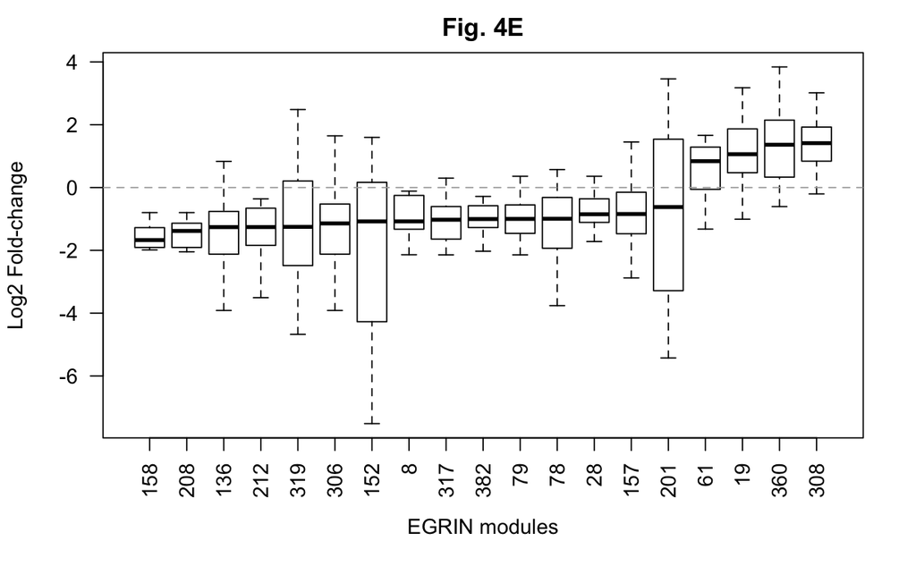

```r
cd24.vs.pbi24<-cbind(cd24.vs.pbi24,temporal.names)
colnames(cd24.vs.pbi24)[4]<-"CD630_locus_tag"
#delete rows without locus tag
cd24.vs.pbi24<-cd24.vs.pbi24[grep("N/A",cd24.vs.pbi24$CD630_locus_tag,invert = T),]
#define significantly upregulated genes
DEGs.up<-cd24.vs.pbi24$CD630_locus_tag[which(cd24.vs.pbi24$log2FoldChange>1 & cd24.vs.pbi24$padj < 0.05)]
#remove duplicates
DEGs.up<-unique(DEGs.up)
#remove genes without CD630 locus tag
DEGs.up<-DEGs.up[grep("CD630_",DEGs.up)]
#define significantly downregulated genes
DEGs.down<-cd24.vs.pbi24$CD630_locus_tag[which(cd24.vs.pbi24$log2FoldChange < -1 & cd24.vs.pbi24$padj < 0.05)]
#remove duplicates
DEGs.down<-unique(DEGs.down)
#remove genes without CD630 locus tag
DEGs.down<-DEGs.down[grep("CD630_",DEGs.down)]
#identify modules enriched with up- or down-regulated genes
enriched.biclusters.cd24.vs.pbi24.up<-evaluate.bicluster.enrichment(cdiff.biclusters.list,DEGs.up,overlap.threshold = 5,adj.p.val.threshold = 0.05)
enriched.biclusters.cd24.vs.pbi24.down<-evaluate.bicluster.enrichment(cdiff.biclusters.list,DEGs.down,overlap.threshold = 5,adj.p.val.threshold = 0.05)
#consolidate enriched modules
modules.cd24.vs.pbi24<-c(rownames(enriched.biclusters.cd24.vs.pbi24.up),rownames(enriched.biclusters.cd24.vs.pbi24.down))
#evaluate functional enrichment of these modules
functionally.enriched.modules.cd24.vs.pbi24<-c()
for(t in function.terms[-7])
{
  current.term.genes<-as.character(cd630.girinathan.annotation$CD630_locus_tag[which(cd630.girinathan.annotation$Pathway1 == t)])
  modules.enriched.with.current.term<-evaluate.bicluster.enrichment(cdiff.biclusters.list,current.term.genes,overlap.threshold = 5,adj.p.val.threshold = 0.05)
  diff.exp.modules.enriched.with.term<-intersect(modules.enriched.with.current.term[,"Module"],modules.cd24.vs.pbi24)
  if(length(diff.exp.modules.enriched.with.term)>0 & length(modules.enriched.with.current.term)>0)
  {
    functionally.enriched.modules.cd24.vs.pbi24<-rbind(functionally.enriched.modules.cd24.vs.pbi24,
                                                        cbind(rep(t,length(diff.exp.modules.enriched.with.term)),diff.exp.modules.enriched.with.term))
  }
}
colnames(functionally.enriched.modules.cd24.vs.pbi24)<-c("Regulon","Module")
#evaluate enrichment with TF regulons
cd24.vs.pbi24.modules.enriched.with.regulons<-c()
for(tf in TF.regulons)
{
  tf.regulon<-as.character(TF.regulons.compilation[which(TF.regulons.compilation[,1]==tf),2])
  modules.enriched.current.regulon<-evaluate.bicluster.enrichment(cdiff.biclusters.list,tf.regulon,overlap.threshold = 5,adj.p.val.threshold = 0.05)
  diff.exp.modules.enriched.with.regulons<-intersect(modules.enriched.current.regulon[,"Module"],modules.cd24.vs.pbi24)
  if(length(diff.exp.modules.enriched.with.regulons)>0 & length(modules.enriched.current.regulon)>0)
  {
    cd24.vs.pbi24.modules.enriched.with.regulons<-rbind(cd24.vs.pbi24.modules.enriched.with.regulons,
                                                 cbind(rep(tf,length(diff.exp.modules.enriched.with.regulons)),diff.exp.modules.enriched.with.regulons))
  }
}
colnames(cd24.vs.pbi24.modules.enriched.with.regulons)<-c("Regulon","Module")
#define set of interesting modules (i.e., enriched with TF regulons and/or functional terms)
selected.modules.cd24.vs.pbi24<-union(cd24.vs.pbi24.modules.enriched.with.regulons[,"Module"],
                                      functionally.enriched.modules.cd24.vs.pbi24[,"Module"])
#plot selected modules
boxplot.median.changes<-c()
filtered.modules<-c()
for(m in selected.modules.cd24.vs.pbi24)
{
  current.module<-as.character(cdiff.biclusters.list[[m]])
  #log2 fold-change of genes in the module
  module.fc<-cd24.vs.pbi24$log2FoldChange[cd24.vs.pbi24$CD630_locus_tag %in% current.module]
  #Filter out modules with median absolute fold-change < 0.5
  if(median(module.fc)>= 0.5 | median(module.fc) <= -0.5)
  {
    filtered.modules<-c(filtered.modules,m)
    boxplot.median.changes<-c(boxplot.median.changes,median(module.fc))
  }
}
names(boxplot.median.changes)<-filtered.modules
#rank modules based on median fold-change
ordered.modules<-filtered.modules[order(boxplot.median.changes,decreasing = T)]
boxplot.module<-c()
boxplot.fold.changes<-c()
for(m in ordered.modules)
{
  current.module<-as.character(cdiff.biclusters.list[[m]])
  module.fc<-cd24.vs.pbi24$log2FoldChange[cd24.vs.pbi24$CD630_locus_tag %in% current.module]
  boxplot.fold.changes<-c(boxplot.fold.changes,module.fc)
  boxplot.module<-c(boxplot.module,rep(m,length(module.fc)))
}
#save values in data frame for Fig. 4E
#multiply by -1 the fold changes
df.pbi24.vs.cd24<-data.frame(boxplot.module,-1*boxplot.fold.changes)
df.pbi24.vs.cd24$boxplot.module<-factor(df.pbi24.vs.cd24$boxplot.module,levels=ordered.modules)
colnames(df.pbi24.vs.cd24)<-c("Module","Fold-change")
boxplot(df.pbi24.vs.cd24$`Fold-change` ~ df.pbi24.vs.cd24$Module,
        ylab="Log2 Fold-change",las=2,main="Fig. 4E",outline=F,xlab="EGRIN modules")
abline(h=0,lty=2,col="darkgrey")
```

6.4 Fig 4D - CD+CSAR24 vs CD24

```r
#read output of differential expression analysis CD+CSAR24 vs CD24 (Girinathan et al. 2020)
cd24.vs.csar24<-read.csv("../Data/Girinathan_transcriptomes/cd_vs_csar_24h.csv")
#remove rows without gene IDs
cd24.vs.csar24<-cd24.vs.csar24[grep("NONE",cd24.vs.csar24$GeneID,invert = T),]
#add CD630 loci names
temporal.names<-c()
for(n in cd24.vs.csar24$GeneID)
{
  gene.position<-which(gene.map.atcc.cd630$ATCC43255_RefSeqID==n)
  if(length(gene.position)>0)
  {
    temporal.names<-c(temporal.names,as.character(gene.map.atcc.cd630$CD630_locus_tag[gene.position[1]]))
    if(length(gene.position)>1)
    {
      print(paste("potential issue:",n,sep=""))
    }
  }
  if(length(gene.position)==0)
  {
    temporal.names<-c(temporal.names,n)
    }
}
```

```
[1] "potential issue:UAB_RS0205925"
[1] "potential issue:UAB_RS0213195"
[1] "potential issue:UAB_RS0208995"
[1] "potential issue:UAB_RS0213190"
[1] "potential issue:UAB_RS02000000220615"
[1] "potential issue:UAB_RS0201110"
[1] "potential issue:UAB_RS02000000220735"
```

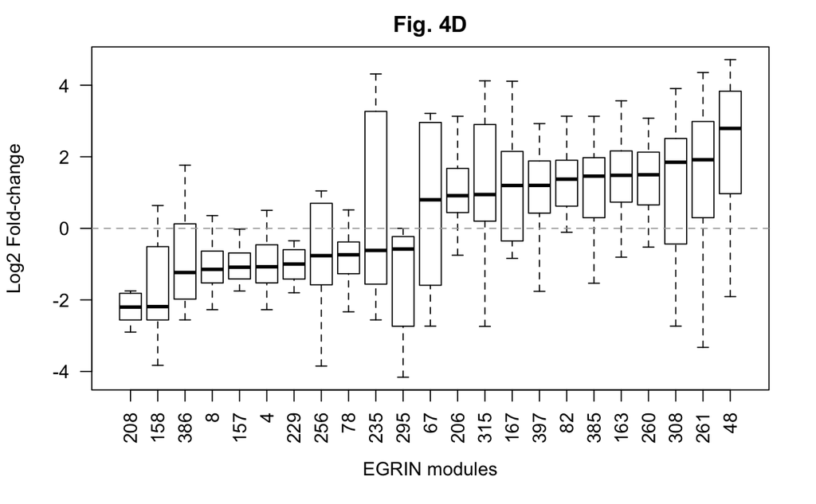

```r
cd24.vs.csar24<-cbind(cd24.vs.csar24,temporal.names)
colnames(cd24.vs.csar24)[4]<-"CD630_locus_tag"
#genes significantly upregulated
DEGs.up<-cd24.vs.csar24$CD630_locus_tag[which(cd24.vs.csar24$log2FoldChange > 1 & cd24.vs.csar24$padj < 0.05)]
#remove duplicates
DEGs.up<-unique(DEGs.up)
#remove genes without loci tags
DEGs.up<-DEGs.up[grep("CD630_",DEGs.up)]
#genes significantly downregulated
DEGs.down<-cd24.vs.csar24$CD630_locus_tag[which(cd24.vs.csar24$log2FoldChange < -1 & cd24.vs.csar24$padj < 0.05)]
#remove duplicates
DEGs.down<-unique(DEGs.down)
#remove genes without loci tags
DEGs.down<-DEGs.down[grep("CD630_",DEGs.down)]
#identify modules enriched with DEGs
enriched.biclusters.cd24.vs.csar24.up<-evaluate.bicluster.enrichment(cdiff.biclusters.list,DEGs.up,overlap.threshold = 5,adj.p.val.threshold = 0.05)
enriched.biclusters.cd24.vs.csar24.down<-evaluate.bicluster.enrichment(cdiff.biclusters.list,DEGs.down,overlap.threshold = 5,adj.p.val.threshold = 0.05)
#consolidate names of enriched modules
modules.cd24.vs.csar24<-c(rownames(enriched.biclusters.cd24.vs.csar24.up),rownames(enriched.biclusters.cd24.vs.csar24.down))
#evaluate functional enrichment of these modules
functionally.enriched.modules.cd24.vs.csar24<-c()
for(t in function.terms[-7])
{
  current.term.genes<-as.character(cd630.girinathan.annotation$CD630_locus_tag[which(cd630.girinathan.annotation$Pathway1 == t)])
  modules.enriched.with.term<-evaluate.bicluster.enrichment(cdiff.biclusters.list,current.term.genes,overlap.threshold = 5, adj.p.val.threshold = 0.05)

  diff.exp.modules.enriched.with.term<-intersect(modules.enriched.with.term[,"Module"],modules.cd24.vs.csar24)
  if(length(diff.exp.modules.enriched.with.term)>0 & length(modules.enriched.with.term)>0)
  {
    functionally.enriched.modules.cd24.vs.csar24<-rbind(functionally.enriched.modules.cd24.vs.csar24,
                                                        cbind(rep(t,length(diff.exp.modules.enriched.with.term)),diff.exp.modules.enriched.with.term))
  }
}
colnames(functionally.enriched.modules.cd24.vs.csar24)<-c("Regulon","Module")
#evaluate enrichment with TF regulons
modules.enriched.with.regulons.cd24.vs.csar24<-c()
for(tf in TF.regulons)
{
  tf.regulon<-as.character(TF.regulons.compilation[which(TF.regulons.compilation[,1]==tf),2])
  enriched.biclusters<-evaluate.bicluster.enrichment(cdiff.biclusters.list,tf.regulon,overlap.threshold = 5,adj.p.val.threshold = 0.05)
  enriched.modules2<-intersect(enriched.biclusters[,"Module"],modules.cd24.vs.csar24)
  if(length( enriched.modules2)>0 & length(enriched.biclusters)>0)
  {
    modules.enriched.with.regulons.cd24.vs.csar24<-rbind(modules.enriched.with.regulons.cd24.vs.csar24,
                                                    cbind(rep(tf,length(enriched.modules2)),enriched.modules2))
  }
}
colnames(modules.enriched.with.regulons.cd24.vs.csar24)<-c("Regulon","Module")
#define set of interesting modules (enriched with TF regulons and/or functional terms)
selected.modules.cd24.vs.csar24<-union(modules.enriched.with.regulons.cd24.vs.csar24[,"Module"],
                                       functionally.enriched.modules.cd24.vs.csar24[,"Module"])
#Plot selected modules
boxplot.median.changes<-c()
filtered.modules<-c()
for(m in selected.modules.cd24.vs.csar24)
{
  current.module<-as.character(cdiff.biclusters.list[[m]])
  module.fc<-cd24.vs.csar24$log2FoldChange[cd24.vs.csar24$CD630_locus_tag %in% current.module]
  #Filter out modules without significant median fold-change
  if(median(module.fc)>= 0.5 | median(module.fc) <= -0.5)
  {
    filtered.modules<-c(filtered.modules,m)
    boxplot.median.changes<-c(boxplot.median.changes,median(module.fc))
  }
}
names(boxplot.median.changes)<-filtered.modules
#order modules according to their median
ordered.modules<-filtered.modules[order(boxplot.median.changes,decreasing = T)]
boxplot.module<-c()
boxplot.fold.changes<-c()
for(m in ordered.modules)
{
  current.module<-as.character(cdiff.biclusters.list[[m]])
  module.fc<-cd24.vs.csar24$log2FoldChange[cd24.vs.csar24$CD630_locus_tag %in% current.module]
  boxplot.fold.changes<-c(boxplot.fold.changes,module.fc)
  boxplot.module<-c(boxplot.module,rep(m,length(module.fc)))
}
#save values in data frame for Fig. 4D
#multiply by -1 the fold changes
df.csar24.vs.cd24<-data.frame(boxplot.module,-1*boxplot.fold.changes)
df.csar24.vs.cd24$boxplot.module<-factor(df.csar24.vs.cd24$boxplot.module,levels=ordered.modules)
boxplot(df.csar24.vs.cd24$X.1...boxplot.fold.changes ~ df.csar24.vs.cd24$boxplot.module,
        ylab="Log2 Fold-change",las=2,main="Fig. 4D",outline=F,xlab="EGRIN modules")
abline(h=0,lty=2,col="darkgrey")
```

7.1. Load Inferelator output to define the TF-gene network required by PRIME

```r
load("../Data/Inferelator/Transcriptional_network_for_PRIME/betas_frac_tp_100_perm_1--frac_fp_0_perm_1_1.1.RData")
load("../Data/Inferelator/Transcriptional_network_for_PRIME/combinedconf_frac_tp_100_perm_1--frac_fp_0_perm_1_1.1.RData")
load("../Data/Inferelator/Transcriptional_network_for_PRIME/params_and_input.RData")
#average regression coefficients among the 100 bootstraps
betas.mean<-matrix(nrow=dim(comb.confs)[1],ncol=dim(comb.confs)[2],0)
for(y in 1:length(betas))
{
  betas.mean<- betas.mean + as.matrix(betas[[y]])
}
combined.betas<- betas.mean/length(betas)
#normalize the original confidence matrix (comb.confs)
normalized.confidence.matrix<-normalization.function(as.matrix(comb.confs))
#evaluate what percentage of the normalized confidence matrix are zeroes
length(which(normalized.confidence.matrix==0))/(3490*301)
```

```
[1] 0.9283582
```

```r
#92.83% of all entries are zero
#create a final table with the TF-module interactions with |beta| >= 0.1
tf.gene.table<-c()
for(t in colnames(combined.betas))
{
  for(m in rownames(combined.betas))
  {
    current.beta<-combined.betas[m,t]
    current.confidence<-normalized.confidence.matrix[m,t]
    if(abs(current.beta) >=0.1)
    {
      temporal.vector<-cbind(t,m,current.confidence,current.beta)
      tf.gene.table<-rbind(tf.gene.table,temporal.vector)
    }
  }
}
colnames(tf.gene.table)<-c("TF","Target","Confidence Score","Beta")
#save table
#write.csv(file="../Data/Inferelator/tf_genes_inferelator_predictions_0.1_betas_WithPriors.csv",tf.gene.table,row.names = F)
```

7.2 Fig. 6A input file- Transcriptional network of PRIME-predicted essential genes

```r
#read PRIME output files
#PRIME-estimated metabolic fluxes
monocolonized.fluxes<-read.csv("../Data/PRIME/output/monocolonized_fluxes.csv",row.names=1)
pbi.cocolonized.fluxes<-read.csv("../Data/PRIME/output/pbi_cocolonized_fluxes.csv",row.names=1)
#PRIME gene essentiality predictions
monocolonized.gene.essentiality<-read.csv("../Data/PRIME/output/essential_genes_monocolonized.csv")
pbi.cocolonized.gene.essentiality<-read.csv("../Data/PRIME/output/essential_genes_cocolonized.csv")
#define essential genes for each condition (mono- and co-colonized) in the WT genotype
monocolonized.essential.genes<-monocolonized.gene.essentiality[which(monocolonized.gene.essentiality[,"WT"]=="ESS"),"Genes"]
pbi.cocolonized.essential.genes<-pbi.cocolonized.gene.essentiality[which(pbi.cocolonized.gene.essentiality[,"WT"]=="ESS"),"Genes"]
#miscellaneous function to convert locus tag in standard name
locus.tag.translation<-function(locus.tag)
{
  output<-locus.tag
  sd.name<-as.character(cdiff.genome.annotation[which(cdiff.genome.annotation$locus_tag == locus.tag),"gene"])
  if(sd.name !="")
  {
    output<-sd.name
  }
  output
}
#define tf-metabolic essential gene interactions predicted by the Inferelator
biotapestry.table<-c()
#complete set of essential genes in the in vivo condition
invivo.essential.genes<-union(monocolonized.essential.genes,pbi.cocolonized.essential.genes)
#focus on essential genes with predicted transcriptional regulators
essential.genes.with.regulators<-c()
for(g in invivo.essential.genes)
{
  #this variable contains the name to be used in the table we are generating
  gene.common.name<-locus.tag.translation(g)
  #define transcriptional regulators of the current gene using the Inferelator network generated above
  regulators.of.current.gene<-tf.gene.table[which(tf.gene.table[,"Target"]==g),"TF"]
  if(length(regulators.of.current.gene)>0)
  {
  essential.genes.with.regulators<-c(essential.genes.with.regulators,g)
  #save the regression coefficients
  current.betas<-sign(as.numeric(tf.gene.table[which(tf.gene.table[,"Target"]==g),"Beta"]))
  #save the pathways the gene is associated with in the metabolic model
  current.pathways<-union(as.character(monocolonized.fluxes[grep(g,monocolonized.fluxes[,"GPR"]),"Subsystem"]),as.character(pbi.cocolonized.fluxes[grep(g,pbi.cocolonized.fluxes[,"GPR"]),"Subsystem"]))
  #merge pathways in a single '-' separated character
  if(length(current.pathways)>1)
  {
    current.pathways<-paste(current.pathways,collapse="-")
  }
  #create raw table for BioTapestry input file
  #change TF loci tags to standard gene names
    for(k in 1:length(regulators.of.current.gene))
    {
      tf<-as.character(regulators.of.current.gene[k])
      regulators.of.current.gene[k]<-locus.tag.translation(tf)
    }
    biotapestry.table<-rbind(biotapestry.table,cbind(rep("gene",length(regulators.of.current.gene)),
                        regulators.of.current.gene,rep("gene",length(regulators.of.current.gene)),rep(gene.common.name, length(regulators.of.current.gene)),
                                                     current.betas,rep("TFs",length(regulators.of.current.gene)),
                        rep(current.pathways,length(regulators.of.current.gene))))
  }
}
colnames(biotapestry.table)<-c("Source Type","Source Name","Target Type","Target Name","Sign","Source Region","Target Region")
#remove interactions involving target genes associated with the 'Biomass' term
biotapestry.table<-biotapestry.table[-1*grep("Biomass",biotapestry.table[,"Target Region"]),]
#count number of essential targets of each TF in the subnetwork
tf.outdegree<-table(biotapestry.table[,"Source Name"])
#save names that will be combined into a meta-regulator (names 'Others')
tfs.to.be.renamed<-as.character(names(which(tf.outdegree < 2)))
#create final table
biotapestry.table.v2<-as.matrix(biotapestry.table)
for(r in tfs.to.be.renamed)
{
  current.tf.position<-which(biotapestry.table.v2[,"Source Name"]==r)
  biotapestry.table.v2[current.tf.position,"Source Name"]<-"Others"
}
```

7.3 Fig. 6B (draft)

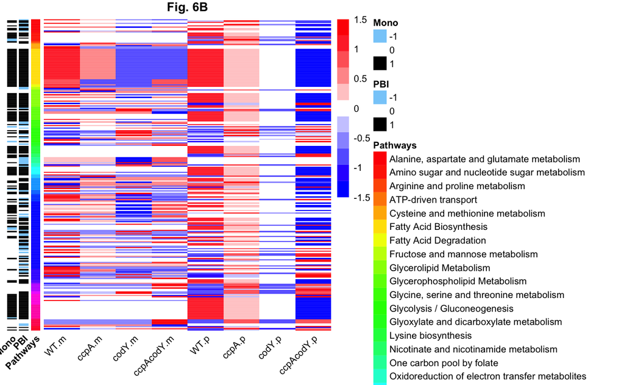

```r
#function to z-score transform a given vector
zscore<-function(vect)
{
  mean.vect<-mean(vect)
  sd.vect<-sd(vect)
  output<- (vect - mean.vect)/sd.vect
  output<-round(output,digits = 5)
  as.numeric(output)
}
#define set of metabolic reactions included in PRIME models
metabolic.reactions<-union(rownames(monocolonized.fluxes),rownames(pbi.cocolonized.fluxes))
#remove empty pathway, exchange, secretion, transport of unknown function,diffusion related reactions
metabolic.reactions<-metabolic.reactions[-1*c(742,47:54,77:140,665,688,334:450,690,692,
495:527,689,691,693:712,550:571,741)]
pathways.metabolic.reactions<-rep("NA",length(metabolic.reactions))
names(pathways.metabolic.reactions)<-metabolic.reactions
#initialize Z-score matrices
monocolonized.zscores<-matrix(nrow=length(metabolic.reactions),ncol=5,dimnames = list(metabolic.reactions,c("Pathway","WT.m","ccpA.m", "codY.m", "ccpAcodY.m")),"NA")
pbi.cocolonized.zscores<-matrix(nrow=length(metabolic.reactions),ncol=5,dimnames = list(metabolic.reactions,c("Pathway","WT.p","ccpA.p", "codY.p", "ccpAcodY.p")),"NA")
#read information regarding PRIME-predicted reactions essentiality
essential.reactions.monocolonized<-read.csv("../Data/PRIME/output/monocolonized_essential_reactions.csv",header=T,row.names=1)
essential.reactions.pbi.cocolonized<-read.csv("../Data/PRIME/output/pbi_essential_reactions.csv",header=T,row.names=1)
reactions.essentiality.matrix<-matrix(nrow=length(metabolic.reactions),ncol=2,dimnames = list(metabolic.reactions,c("Mono","PBI")),-1)
for(rx in metabolic.reactions)
{
  reaction.position.mono<-which(rownames(monocolonized.fluxes)==rx)
  reaction.position.pbi<-which(rownames(pbi.cocolonized.fluxes)==rx)
  if(length(reaction.position.mono)!=0)
  {
    #'0' indicates not essential reactions
    if(essential.reactions.monocolonized[rx,"WT"] == "nonESS")
    {
    reactions.essentiality.matrix[rx,1]<-0
    }
    #'1' indicates not essential reactions
    if(essential.reactions.monocolonized[rx,"WT"] != "nonESS")
    {
      reactions.essentiality.matrix[rx,1]<- 1
    }
    #raw flux vector
    temporal.vector<-as.numeric(monocolonized.fluxes[reaction.position.mono,4:7])
    #save name of pathways associated with current reaction
    pathways.metabolic.reactions[rx]<-as.character(monocolonized.fluxes[reaction.position.mono,"Subsystem"])
    #if all flux values are the same (including zero)
    if(length(unique(temporal.vector))==1)
    {
      monocolonized.zscores[rx,]<-as.matrix(c(pathways.metabolic.reactions[rx],rep("NA",4)))
    }
    #else
    if(length(unique(temporal.vector))>1)
    {
      monocolonized.zscores[rx,]<-as.matrix(c(pathways.metabolic.reactions[rx],zscore(temporal.vector)))
    }
  }
  #similar procedure for the pbi co-colonized flux vectors
  if(length(reaction.position.pbi)!=0)
  {
    if(essential.reactions.pbi.cocolonized[rx,"WT"] == "nonESS")
    {
      reactions.essentiality.matrix[rx,2]<-0
    }
    if(essential.reactions.pbi.cocolonized[rx,"WT"] != "nonESS")
    {
      reactions.essentiality.matrix[rx,2]<- 1
    }
    pathways.metabolic.reactions[rx]<-as.character(pbi.cocolonized.fluxes[reaction.position.pbi,"Subsystem"])
    temporal.vector<-as.numeric(pbi.cocolonized.fluxes[reaction.position.pbi,4:7])
    #if all flux values are the same (including zero)
    if(length(unique(temporal.vector))==1)
    {
      pbi.cocolonized.zscores[rx,]<-as.matrix(c(pathways.metabolic.reactions[rx],rep("NA",4)))
    }
    if(length(unique(temporal.vector))>1)
    {
      pbi.cocolonized.zscores[rx,]<-as.matrix(c(pathways.metabolic.reactions[rx],zscore(temporal.vector)))
    }

  }
}
#combine the two zscore.matrices
full.zscore.matrix<-cbind(monocolonized.zscores[,2:5],pbi.cocolonized.zscores[,2:5])
#order matrices according to alphabetical order of the corresponding pathways
full.zscore.matrix<-full.zscore.matrix[order(pathways.metabolic.reactions),]
reactions.essentiality.matrix<-reactions.essentiality.matrix[order(pathways.metabolic.reactions),]
pathways.metabolic.reactions<-pathways.metabolic.reactions[order(pathways.metabolic.reactions)]
write.csv(file="../Data/PRIME/output/zscored_fluxes.csv",full.zscore.matrix)
full.zscore.matrix.v1<-read.csv(file="../Data/PRIME/output/zscored_fluxes.csv",row.names = 1,header=T)
full.zscore.matrix.v1<-as.matrix(full.zscore.matrix.v1)
#remove rows that only contain ''NA' values
na.count<-sapply(1:nrow(full.zscore.matrix.v1),function(x){length(which(is.na(full.zscore.matrix.v1[x,])))})
full.zscore.matrix.v2<-full.zscore.matrix.v1[-1*which(na.count==8),]
#convert remaining 'NA' values to zero
full.zscore.matrix.v3<-full.zscore.matrix.v2
full.zscore.matrix.v3[which(is.na(full.zscore.matrix.v2))]<-0
full.zscore.matrix.v3<-as.data.frame(full.zscore.matrix.v3)
#compare the fluxes of the two networks for WT C. difficile genotype
Pathways<-pathways.metabolic.reactions[-1*which(na.count==8)]
Mono<-reactions.essentiality.matrix[-1*which(na.count==8),1]
PBI<-reactions.essentiality.matrix[-1*which(na.count==8),2]
#create temporal dataframe
temporal.df<-as.data.frame(cbind(Pathways,PBI,Mono))
#define color palettes
pathways.colors<-rainbow(length(unique(Pathways)))
names(pathways.colors)<-unique(temporal.df$Pathways)
mono.essentiality.colors<-c("lightskyblue","white","black")
names(mono.essentiality.colors)<-c(-1,0,1)
pbi.essentiality.colors<-mono.essentiality.colors
#Fig. 6B
pheatmap(full.zscore.matrix.v3,
         border_color = "black",color =bluered(11),scale = "none",cluster_rows=F,
         cluster_cols = F,fontsize = 8, annotation_row = temporal.df, show_rownames=F,angle_col=45,annotation_colors = list(Pathways= pathways.colors,Mono=mono.essentiality.colors,PBI=pbi.essentiality.colors),main="Fig. 6B")
```